# Characterization of White Matter and Cerebrospinal Fluid Biomarker Associations in Alzheimer’s Disease

Nik Padmanabhan

### Overview

This project aims to find associations between white matter content and CSF biomarker levels in Alzheimer’s patients, using Alzheimer’s Disease neuroimaging initiative (ADNI) data. Although Alzheimer’s disease primarily affects grey matter, results of this work could improve early characterization of the disease. This project would not have been possible without Choonsik Lee’s recommendations for dicom image visualization, Taki Shinohara’s help with FSLR, and Konrad Kording’s recommendations of machine learning approaches. A link to my GitHub repository is included:

https://github.com/nikpad/BMIN503_Final_Project

### Introduction

Alzheimer’s disease, which is a progressive, chronic, neurodegenerative disease, currently affects almost 6 million Americans. There is currently no cure or method to stop its progression. After diagnosis, the life expectancy of patients generally ranges from 3-10 years. The disease, characterized by extracellular amyloid beta deposits and neurofibrillary tangles, primarily affects grey matter in the brain. However, white matter abnormalities also exist, although these changes take place prior to the neurodegenerative process. Patients with preclinical Alzheimer’s disease, before substantial changes of the grey matter have happened, have been shown to have similar levels of white matter abnormalities as patients in later stages. These abnormalities generally include myelin and oligodendrocyte loss. Assiciations between white matter content and cerebrospinal fluid biomarkers, such as amyloid beta and tau proteins, could improve the understanding of the pathogenesis of Alzheimer’s disease, which could improve and expedite the development of treatments.

This analysis was facilitated by the ADNI, in which multiple types of data, including clinical, imaging, and biospecimen data, were collected from both affected and control populations. The imaging data must be treated differently than the other data types, as quantitative values were first extracted for comparison. The R packages oro.dicom and oro.nifti enable analyzing MRI data, for processes such as visualization and segmentation. In this work, segmentation based on overall pixel intensities was used to estimate white matter content. In addition, toolkits in R such as ANTs and FSL enable image preprocessing procedures such as image registration, brain extraction, and inhomogeneity correction. Once numerical values have been extracted from the image data, statistical models can be developed to better understand the characteristics Alzheimer’s disease. An end goal of this work would be for supervised machine learning algrithms to be able to predict disease progression of patients in early stages. This work will hopefully impact the understanding of the disease over time, and therefore improve the development of treatments.

### Methods

Project data included both biomarker and T2 weighted MRI images for 60 patients. Biomarker data included both baseline and 12 month data for amyloid beta, tau, and p-tau. Of the 60 patients, 30 were from a cognitively normal (CN) group, and 30 were from an Alzheimer’s Disease (AD) group. For MRI data, individual dicom files were converted to a nifti file for easier manipulation. Afterwards, the images’ intensities were transformed to improve visualization. Brain extraction was carried out with FSLR, and image segmentation was carried out based on each image’s intensity histogram to estimate white matter content. A representative process is shown in this section, and this process is completed for the rest of the 60 patients in the results section. Hierarchical clustering and random forests were used to compare biomarker, white matter content, and their combination’s ability to cluster and predict cognitive state. Additionally, baseline and 12 month data were compared to assess disease progression.

```r
library(devtools)
library(oro.dicom)
library(oro.nifti)
```

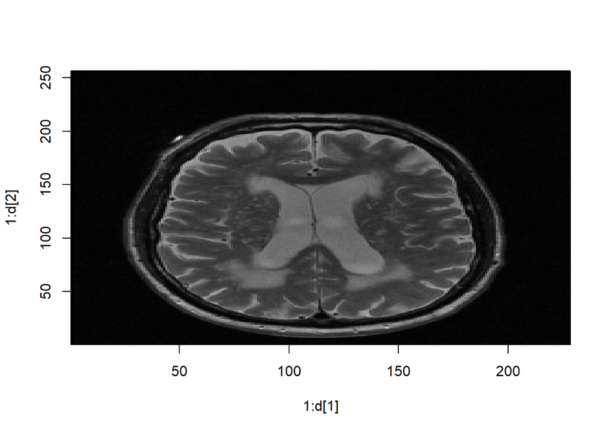

```r
#Visualize individual slice
setwd("C:/Users/Nik/Documents/ADTest/ADNI/011_S_0003/Axial_PD-T2_TSE/2005-09-01_10_46_12.0/S9126")
slice = readDICOM("ADNI_011_S_0003_MR_Axial_PD-T2_TSE__br_raw_20050901115113886_94_S9126_I7062.dcm")

d=dim(t(slice$img[[1]]))
image(1:d[1],1:d[2], t(slice$img[[1]]),col=gray(0:64/64))
```

```r
setwd("C:/Users/Nik/Documents/ADTest/ADNI/011_S_0003/Axial_PD-T2_TSE/2005-09-01_10_46_12.0/")
all_slices = readDICOM("S9126")

dim(all_slices$img[[36]])
```

```
## [1] 256 228
```

```r
#Convert to NIfTI
nii=dicom2nifti(all_slices)
d=dim(nii);
d
```

```
## [1] 228 256  58
```

```r
#Visualize single NIfTI image
class(nii)
```

```
## [1] "nifti"
## attr(,"package")
## [1] "oro.nifti"
```

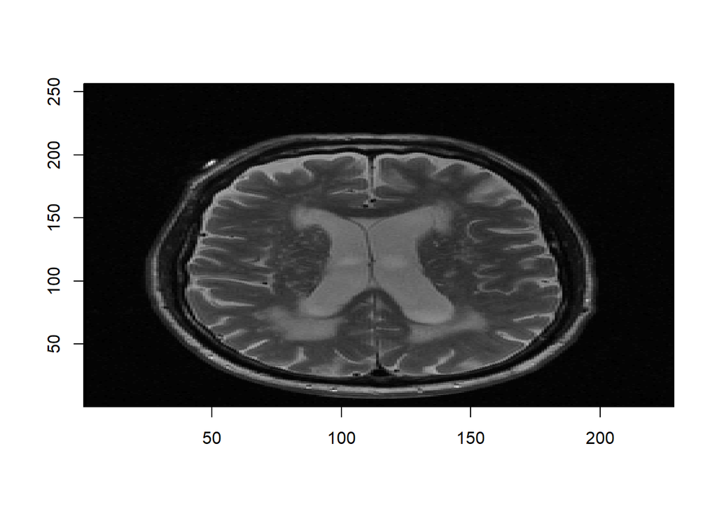

```r
image(1:d[1], 1:d[2], nii[,,36], col=gray(0:64/64), xlab="",ylab="")
```

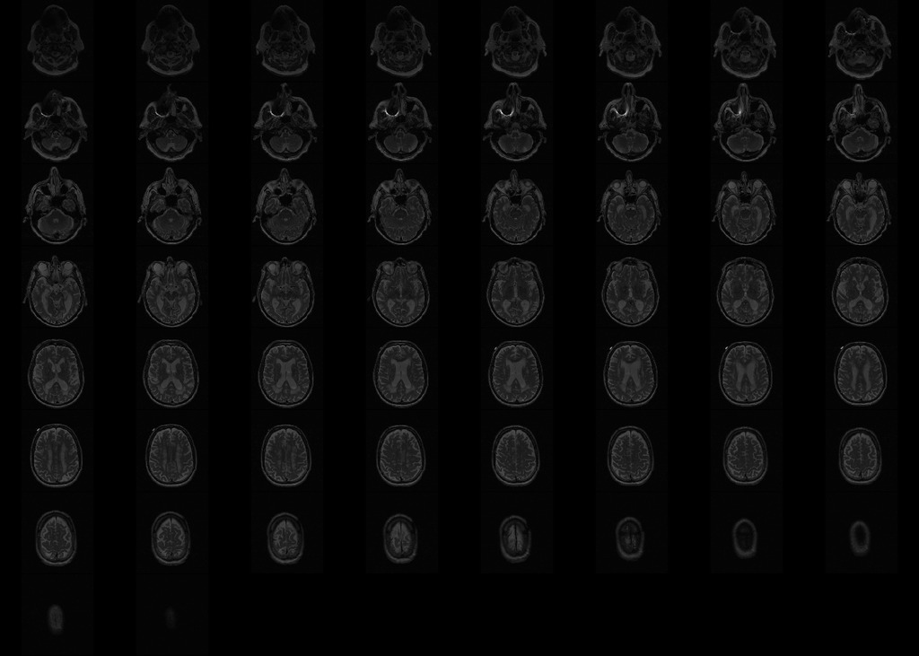

```r
#Visualize entire stack
image(nii)
```

All dicom images in a stack were converted to a nifti stack, enabling visualization of all stacks simultaneously. It is much simpler to work with nifti images in R.

```r
slice$img[[1]][101:105,121:125]
```

```
##      [,1] [,2] [,3] [,4] [,5]
## [1,]  837  810  813  800  817
## [2,]  829  811  824  796  830
## [3,]  814  802  795  765  808
## [4,]  809  769  783  775  817
## [5,]  821  774  818  795  824
```

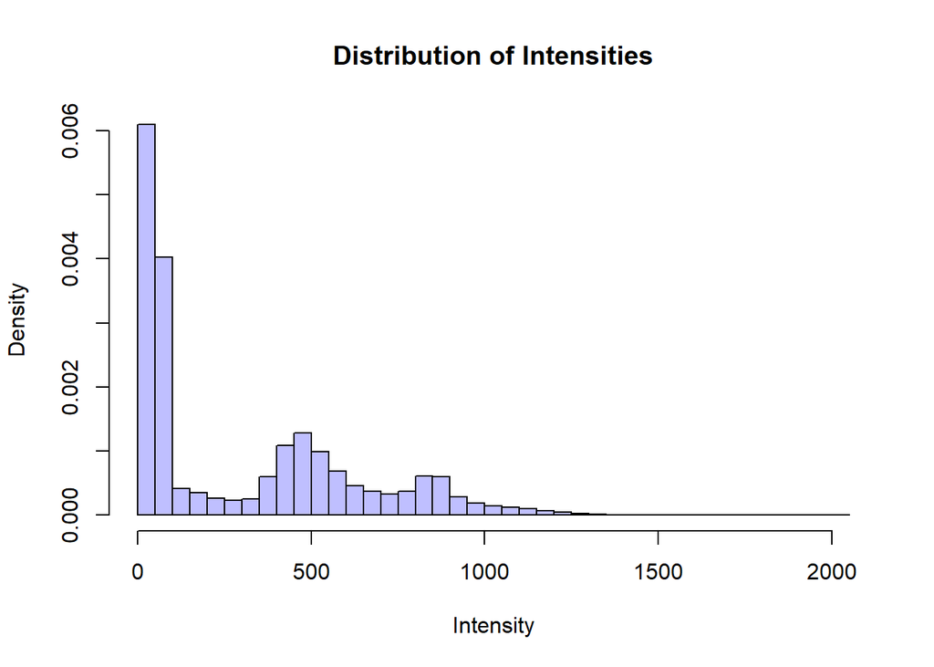

```r
hist(slice$img[[1]][,],breaks=50, xlab="Intensity",prob=T, col=rgb(0,0,1,1/4), main="Distribution of Intensities")
```

The second peak, centered around 500, corresponds to white matter.

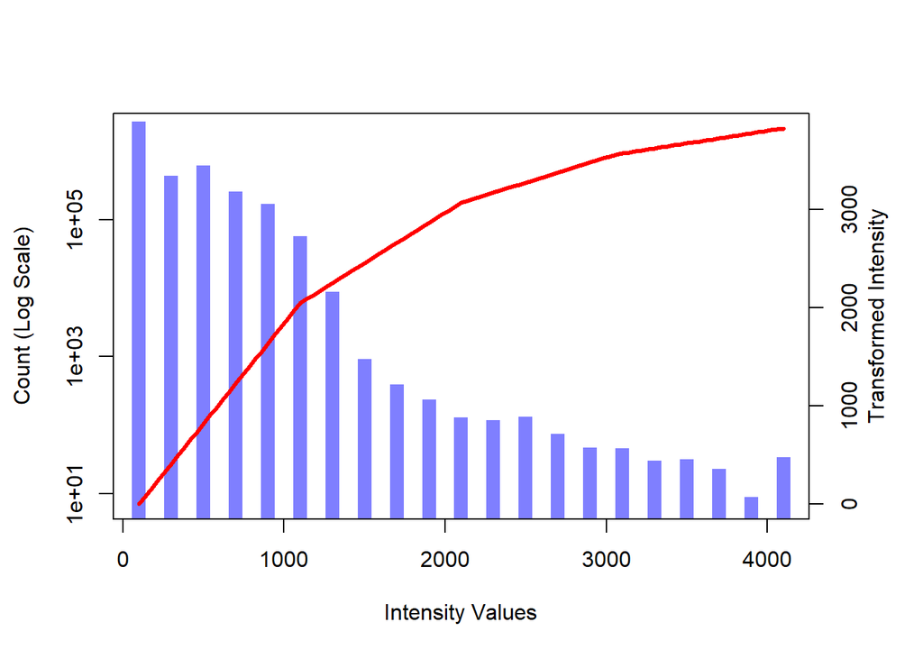

```r
im_hist<-hist(nii,plot=FALSE)
par(mar = c(5, 4, 4, 4) + 0.3)
col1=rgb(0,0,1,1/2)
plot(im_hist$mids,im_hist$count,log="y",type='h',lwd=10, lend=2,col=col1,xlab="Intensity Values",ylab="Count (Log Scale)" )


#Define a different transfer function
lin.sp<-function(x,knots,slope){
    knots<-c(min(x),knots,max(x))
    slopeS<-slope[1]
 for(j in 2:length(slope)){
   slopeS<-c(slopeS,slope[j]-sum(slopeS))}
   rvals<-numeric(length(x))
 for(i in 2:length(knots)){
   rvals<-ifelse(x>=knots[i-1], slopeS[i-1]*(x-knots[i-1])+rvals,rvals)}
 return(rvals)}
#Define a spline with three knots and four slopes
knot.vals<-c(.25,.5,.74)
slp.vals<-c(2,1,.5,.25)
#knot.vals<-c(0.5)
#slp.vals<-c(1,1)


#Plot the Spline Transfer Function
par(new = TRUE)
curve(lin.sp(x,knot.vals,slp.vals),axes=FALSE,xlab="",ylab="",col=2,lwd=3)
axis(side=4,at = pretty(range(im_hist$mids))/max(nii),labels=pretty(range(im_hist$mids)))
mtext("Transformed Intensity", side=4, line=2)
```

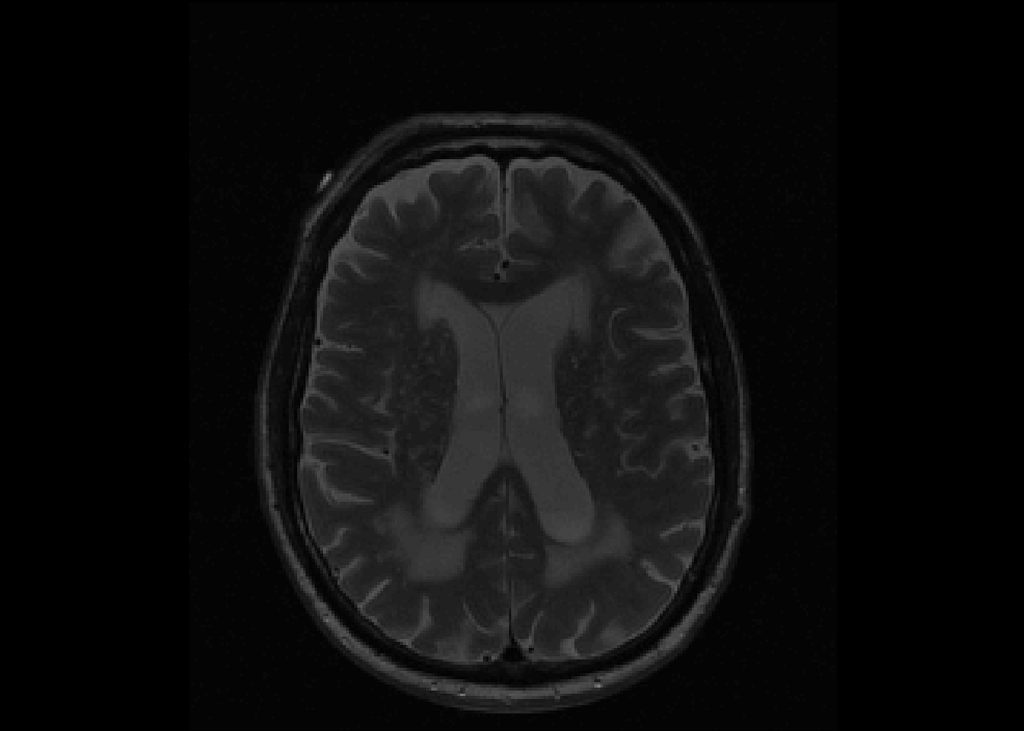

```r
trans<-lin.sp(nii, knot.vals*max(nii), slp.vals)
image(nii,z=36,plot.type='single', main="Original Image")
```

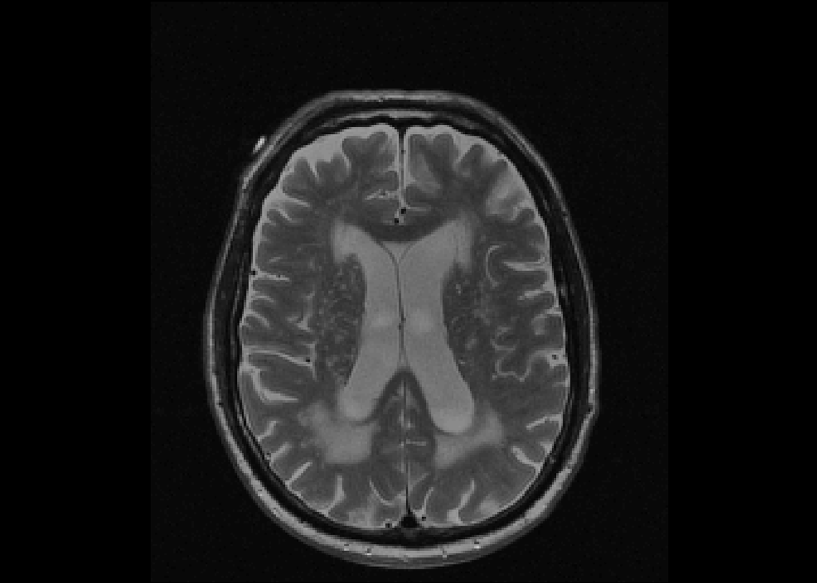

```r
image(trans,z=36,plot.type='single',main="Transformed Image")
```

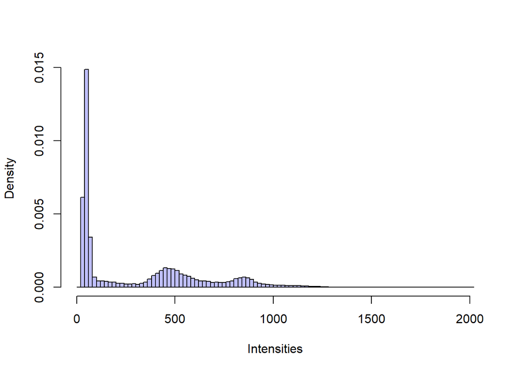

```r
#Original Image Histogram
s2 <- nii[,,36]
hist(s2[s2>0],breaks=100, xlab="Intensities", prob=T, col=rgb(0,0,1,1/4), main="")
```

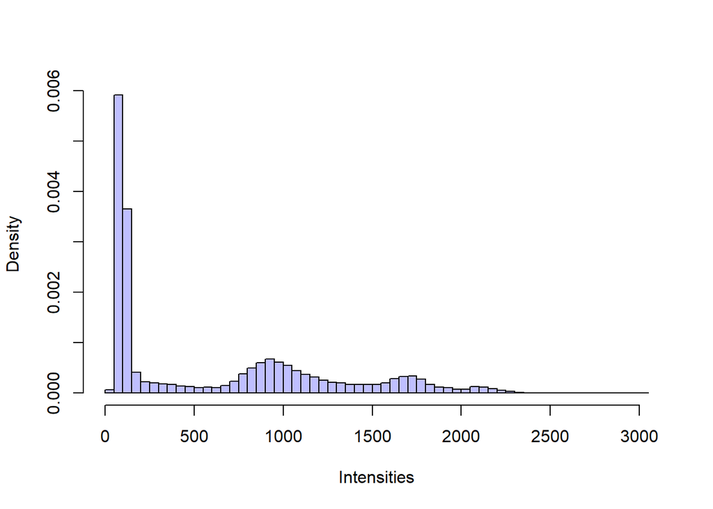

```r
#Transformed Image Histogram
s3 <- trans[,,36]
hist(s3[s3>0],breaks=100, xlab="Intensities", prob=T, col=rgb(0,0,1,1/4), main="")
```

```r
#setwd("C:/Users/Nik/Documents/ADTest/ADNI/011_S_0003/Axial_PD-T2_TSE/2005-09-01_10_46_12.0/S9126")
#fname="Test_nifti_File"
#writeNIfTI(nim=trans,filename=fname)
```

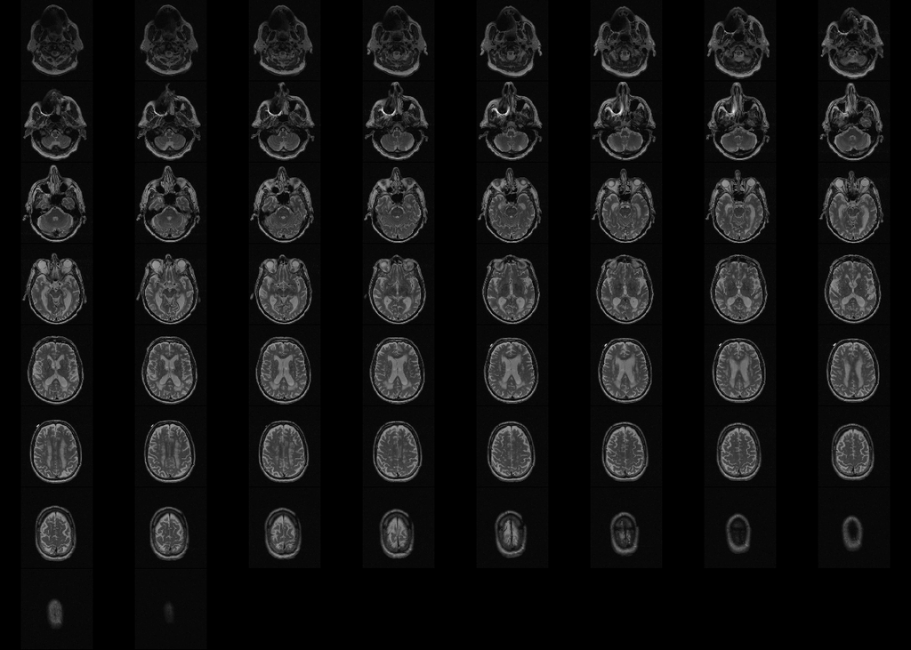

```r
image(trans)
```

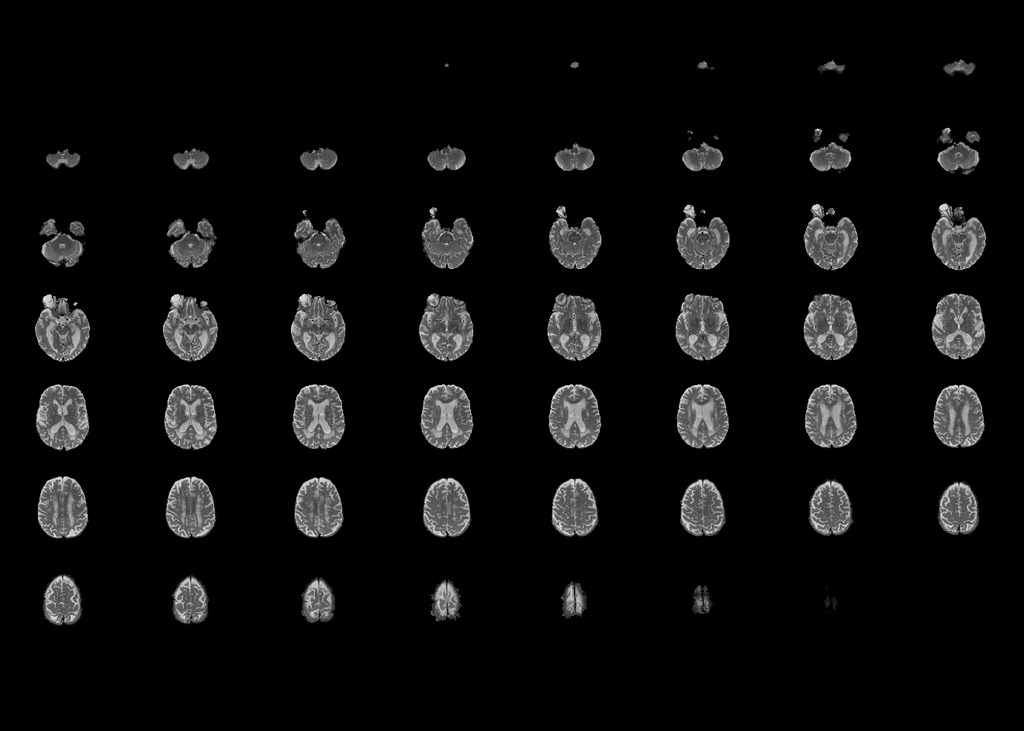

```r
#Brain extraction using FSLR from a virtual machine
#bet_img = fslbet(infile=nii, retimg=TRUE)

#Brain Extracted Image:
setwd("C:/Users/Nik/Documents/ADTest/ADNI/011_S_0003/Axial_PD-T2_TSE/2005-09-01_10_46_12.0/")
sstrip = readNIfTI("newimg.nii.gz")
image(sstrip)
```

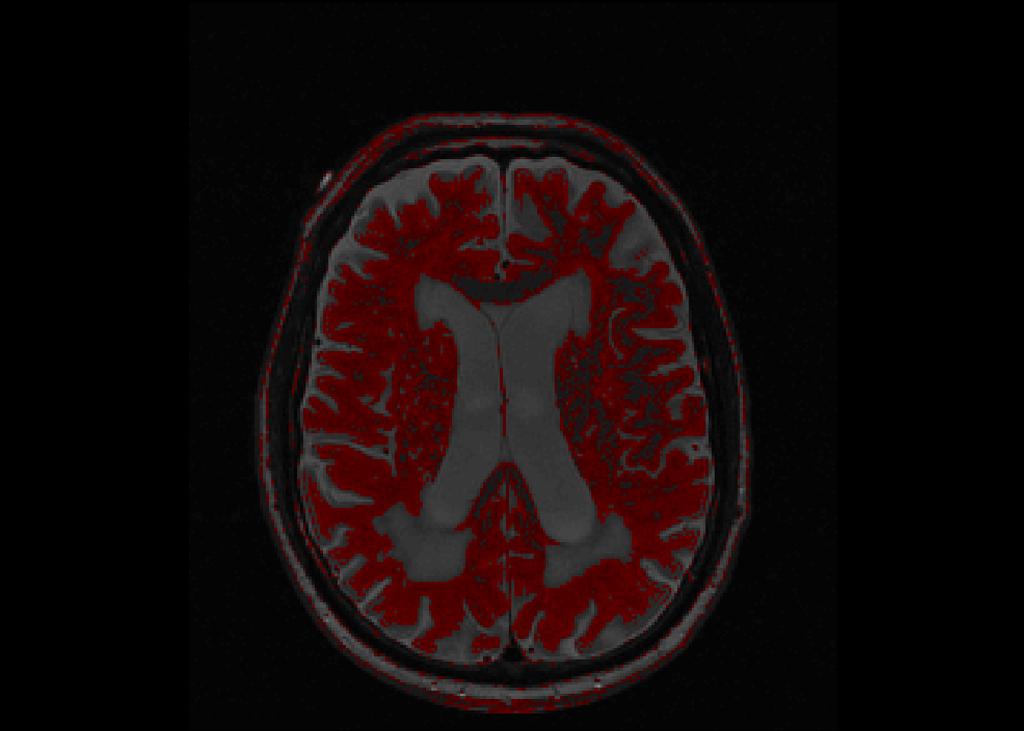

```r
#Original Image
is_btw_400_600<- ((nii>400) & (nii<600)) #1 or 0 for each voxel
nii_mask<-nii
nii_mask[!is_btw_400_600]=NA
overlay(nii,nii_mask,z=36,plot.type="single")
```

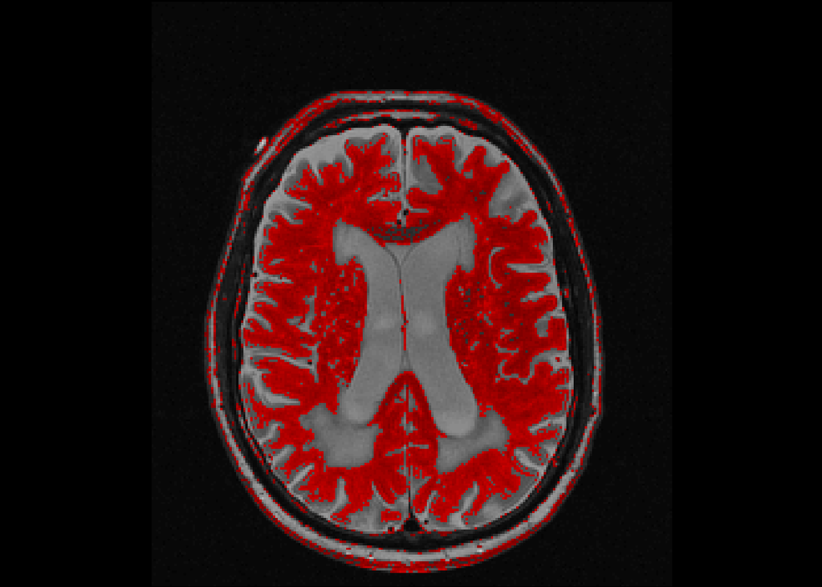

```r
#Transformed Image
is_btw_700_1150<- ((trans>700) & (trans<1150)) #1 or 0 for each voxel
trans_mask<-trans
trans_mask[!is_btw_700_1150]=NA
overlay(trans,trans_mask,z=36,plot.type="single")
```

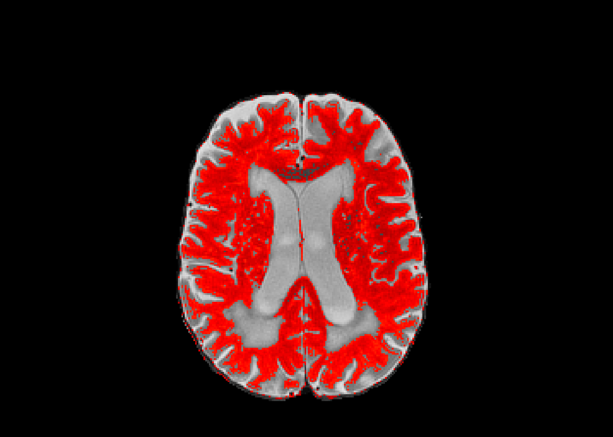

```r
#Transformed and Brain-extracted Image
is_btw_700_1150<- ((sstrip>700) & (sstrip<1150)) #1 or 0 for each voxel
sstrip_mask<-sstrip
sstrip_mask[!is_btw_700_1150]=NA
overlay(sstrip,sstrip_mask,z=36,plot.type="single")
```

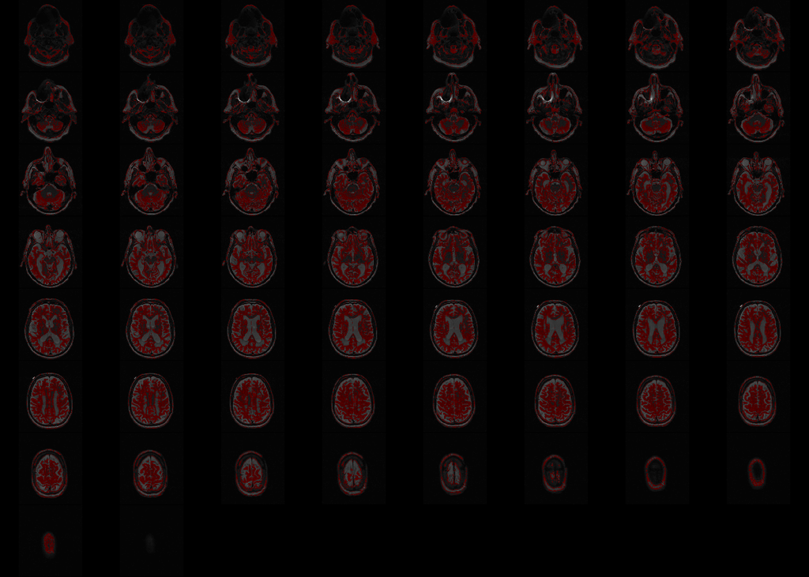

```r
#Original Image Stack
overlay(nii,nii_mask)
```

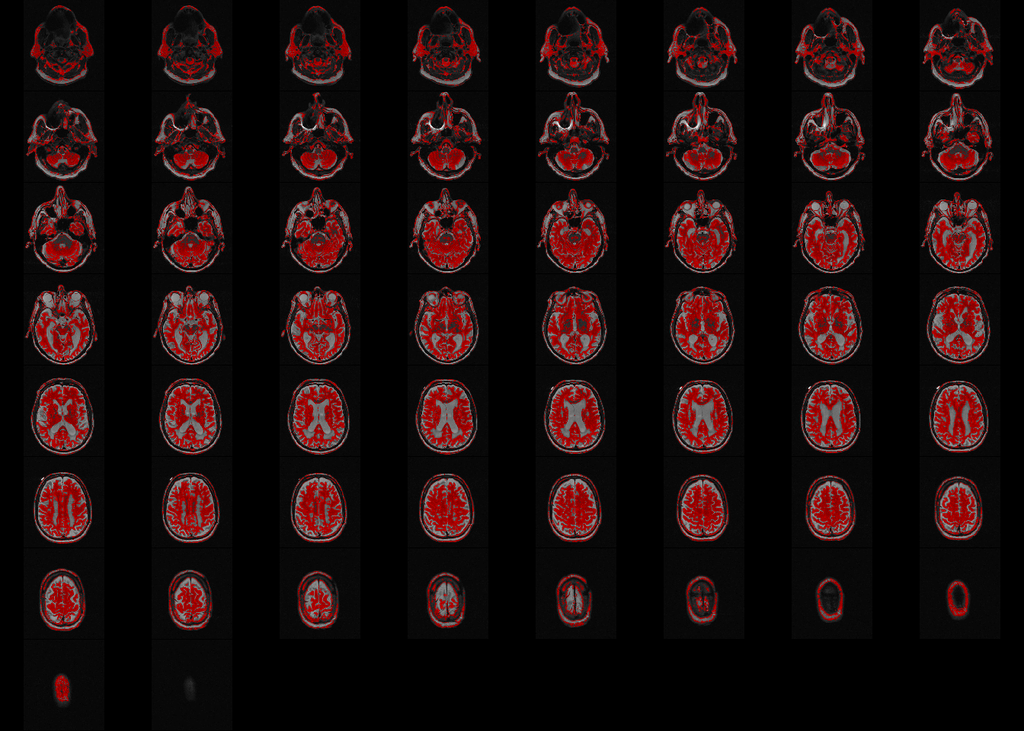

```r
#Transformed Image Stack
overlay(trans,trans_mask)
```

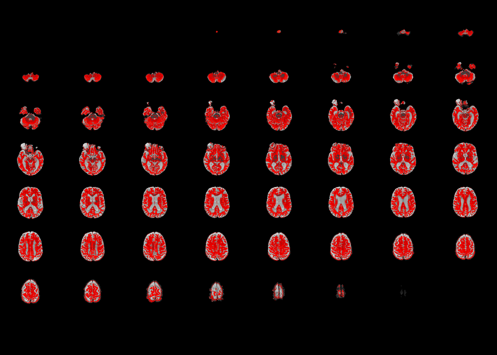

```r
#Transormed and Brain-extracted Image Stack
overlay(sstrip,sstrip_mask)
```

```r
is_positive<- ((sstrip>0)) #1 or 0 for each voxel
#Total:
sum(table(sstrip[is_positive]))
```

```
## [1] 738029
```

```r
#White Matter:
sum(table(sstrip_mask[is_btw_700_1150]))
```

```
## [1] 382126
```

```r
#Ratio
sum(table(sstrip_mask[is_btw_700_1150]))/sum(table(sstrip[is_positive]))
```

```
## [1] 0.5177656
```

### Results

The process for determining the white matter ratio was completed for the other 59 patients, as shown below. The results of the code were saved, obviating the need to rerun the code.

AD Patients

```r
# #3:
# setwd("C:/Users/Nik/Documents/AD/ADNI/003/Axial_PD-T2_TSE/2005-09-01_10_46_12.0")
# all_slices = readDICOM("S9126")
# nii=dicom2nifti(all_slices)
# trans003<-lin.sp(nii, knot.vals*max(nii), slp.vals)
# image(trans003,z=36,plot.type='single',main="Transformed Image")
# setwd("C:/Users/Nik/Documents/AD/Transformed/")
# writeNIfTI(nim=trans003,filename="trans003")
# setwd("C:/Users/Nik/Documents/AD/Brain_Extracted")
# sstrip = readNIfTI("bet003.nii.gz")
# sstrip_slice <- sstrip[,,36]
# hist(sstrip_slice[sstrip_slice>0],breaks=100, xlab="Intensities", prob=T, col=rgb(0,0,1,1/4), main="")
# is_btw_700_1150<- ((sstrip>700) & (sstrip<1150)) #1 or 0 for each voxel
# sstrip_mask<-sstrip
# sstrip_mask[!is_btw_700_1150]=NA
# overlay(sstrip,sstrip_mask,z=36,plot.type="single")
# Ratio003 = sum(table(sstrip_mask[is_btw_700_1150]))/sum(table(sstrip[is_positive]))
# Ratio003
#
# #10:
# setwd("C:/Users/Nik/Documents/AD/ADNI/010/Axial_PD-T2_TSE/2005-11-07_08_40_20.0")
# all_slices = readDICOM("S8798")
# nii=dicom2nifti(all_slices)
# trans010<-lin.sp(nii, knot.vals*max(nii), slp.vals)
# image(trans010,z=36,plot.type='single',main="Transformed Image")
# setwd("C:/Users/Nik/Documents/AD/Transformed/")
# writeNIfTI(nim=trans010,filename="trans010")
# setwd("C:/Users/Nik/Documents/AD/Brain_Extracted")
# sstrip = readNIfTI("bet010.nii.gz")
# sstrip_slice <- sstrip[,,36]
# hist(sstrip_slice[sstrip_slice>0],breaks=100, xlab="Intensities", prob=T, col=rgb(0,0,1,1/4), main="")
# is_btw_700_1150<- ((sstrip>700) & (sstrip<1150)) #1 or 0 for each voxel
# sstrip_mask<-sstrip
# sstrip_mask[!is_btw_700_1150]=NA
# overlay(sstrip,sstrip_mask,z=36,plot.type="single")
# Ratio010 = sum(table(sstrip_mask[is_btw_700_1150]))/sum(table(sstrip[is_positive]))
# Ratio010
#
# #29:
# setwd("C:/Users/Nik/Documents/AD/ADNI/029/Axial_PD-T2_TSE/2005-10-14_09_00_42.0")
# all_slices = readDICOM("S9903")
# nii=dicom2nifti(all_slices)
# trans029<-lin.sp(nii, knot.vals*max(nii), slp.vals)
# image(trans029,z=36,plot.type='single',main="Transformed Image")
# setwd("C:/Users/Nik/Documents/AD/Transformed/")
# writeNIfTI(nim=trans029,filename="trans029")
# setwd("C:/Users/Nik/Documents/AD/Brain_Extracted")
# sstrip = readNIfTI("bet029.nii.gz")
# sstrip_slice <- sstrip[,,36]
# hist(sstrip_slice[sstrip_slice>0],breaks=100, xlab="Intensities", prob=T, col=rgb(0,0,1,1/4), main="")
# is_btw_600_850<- ((sstrip>600) & (sstrip<850)) #1 or 0 for each voxel
# sstrip_mask<-sstrip
# sstrip_mask[!is_btw_600_850]=NA
# overlay(sstrip,sstrip_mask,z=36,plot.type="single")
# Ratio029 = sum(table(sstrip_mask[is_btw_600_850]))/sum(table(sstrip[is_positive]))
# Ratio029
#
# #76:
# setwd("C:/Users/Nik/Documents/AD/ADNI/076/Axial_PD-T2_TSE/2005-12-06_11_49_09.0")
# all_slices = readDICOM("S10467")
# nii=dicom2nifti(all_slices)
# trans076<-lin.sp(nii, knot.vals*max(nii), slp.vals)
# image(trans076,z=36,plot.type='single',main="Transformed Image")
# setwd("C:/Users/Nik/Documents/AD/Transformed/")
# writeNIfTI(nim=trans076,filename="trans076")
# setwd("C:/Users/Nik/Documents/AD/Brain_Extracted")
# sstrip = readNIfTI("bet076.nii.gz")
# sstrip_slice <- sstrip[,,36]
# hist(sstrip_slice[sstrip_slice>0],breaks=100, xlab="Intensities", prob=T, col=rgb(0,0,1,1/4), main="")
# is_btw_650_850<- ((sstrip>650) & (sstrip<850)) #1 or 0 for each voxel
# sstrip_mask<-sstrip
# sstrip_mask[!is_btw_650_850]=NA
# overlay(sstrip,sstrip_mask,z=36,plot.type="single")
# Ratio076 = sum(table(sstrip_mask[is_btw_650_850]))/sum(table(sstrip[is_positive]))
# Ratio076
#
# #83:
# setwd("C:/Users/Nik/Documents/AD/ADNI/083/Axial_PD-T2_TSE/2005-12-14_08_44_38.0")
# all_slices = readDICOM("S10567")
# nii=dicom2nifti(all_slices)
# trans083<-lin.sp(nii, knot.vals*max(nii), slp.vals)
# image(trans083,z=36,plot.type='single',main="Transformed Image")
# setwd("C:/Users/Nik/Documents/AD/Transformed/")
# writeNIfTI(nim=trans083,filename="trans083")
# setwd("C:/Users/Nik/Documents/AD/Brain_Extracted")
# sstrip = readNIfTI("bet083.nii.gz")
# sstrip_slice <- sstrip[,,36]
# hist(sstrip_slice[sstrip_slice>0],breaks=100, xlab="Intensities", prob=T, col=rgb(0,0,1,1/4), main="")
# is_btw_550_800<- ((sstrip>550) & (sstrip<800)) #1 or 0 for each voxel
# sstrip_mask<-sstrip
# sstrip_mask[!is_btw_550_800]=NA
# overlay(sstrip,sstrip_mask,z=36,plot.type="single")
# Ratio083 = sum(table(sstrip_mask[is_btw_550_800]))/sum(table(sstrip[is_positive]))
# Ratio083
#
# #84:
# setwd("C:/Users/Nik/Documents/AD/ADNI/084/Axial_PD-T2_TSE/2006-01-04_09_05_52.0")
# all_slices = readDICOM("S10763")
# nii=dicom2nifti(all_slices)
# trans084<-lin.sp(nii, knot.vals*max(nii), slp.vals)
# image(trans084,z=36,plot.type='single',main="Transformed Image")
# setwd("C:/Users/Nik/Documents/AD/Transformed/")
# writeNIfTI(nim=trans084,filename="trans084")
# setwd("C:/Users/Nik/Documents/AD/Brain_Extracted")
# sstrip = readNIfTI("bet084.nii.gz")
# sstrip_slice <- sstrip[,,36]
# hist(sstrip_slice[sstrip_slice>0],breaks=100, xlab="Intensities", prob=T, col=rgb(0,0,1,1/4), main="")
# is_btw_550_750<- ((sstrip>550) & (sstrip<750)) #1 or 0 for each voxel
# sstrip_mask<-sstrip
# sstrip_mask[!is_btw_550_750]=NA
# overlay(sstrip,sstrip_mask,z=36,plot.type="single")
# Ratio084 = sum(table(sstrip_mask[is_btw_550_750]))/sum(table(sstrip[is_positive]))
# Ratio084
#
# #91:
# setwd("C:/Users/Nik/Documents/AD/ADNI/091/ADNI_______DOUBLE_TSE/2005-12-23_07_21_22.0")
# all_slices = readDICOM("S10707")
# nii=dicom2nifti(all_slices)
# trans091<-lin.sp(nii, knot.vals*max(nii), slp.vals)
# image(trans091,z=36,plot.type='single',main="Transformed Image")
# setwd("C:/Users/Nik/Documents/AD/Transformed/")
# writeNIfTI(nim=trans091,filename="trans091")
# setwd("C:/Users/Nik/Documents/AD/Brain_Extracted")
# sstrip = readNIfTI("bet091.nii.gz")
# sstrip_slice <- sstrip[,,36]
# hist(sstrip_slice[sstrip_slice>0],breaks=100, xlab="Intensities", prob=T, col=rgb(0,0,1,1/4), main="")
# is_btw_300_400<- ((sstrip>300) & (sstrip<400)) #1 or 0 for each voxel
# sstrip_mask<-sstrip
# sstrip_mask[!is_btw_300_400]=NA
# overlay(sstrip,sstrip_mask,z=36,plot.type="single")
# Ratio091 = sum(table(sstrip_mask[is_btw_300_400]))/sum(table(sstrip[is_positive]))
# Ratio091
#
# #93:
# setwd("C:/Users/Nik/Documents/AD/ADNI/093/Axial_PD-T2_TSE/2006-01-03_09_09_25.0")
# all_slices = readDICOM("S10734")
# nii=dicom2nifti(all_slices)
# trans093<-lin.sp(nii, knot.vals*max(nii), slp.vals)
# image(trans093,z=36,plot.type='single',main="Transformed Image")
# setwd("C:/Users/Nik/Documents/AD/Transformed/")
# writeNIfTI(nim=trans093,filename="trans093")
# setwd("C:/Users/Nik/Documents/AD/Brain_Extracted")
# sstrip = readNIfTI("bet093.nii.gz")
# sstrip_slice <- sstrip[,,36]
# hist(sstrip_slice[sstrip_slice>0],breaks=100, xlab="Intensities", prob=T, col=rgb(0,0,1,1/4), main="")
# is_btw_550_800<- ((sstrip>550) & (sstrip<800)) #1 or 0 for each voxel
# sstrip_mask<-sstrip
# sstrip_mask[!is_btw_550_800]=NA
# overlay(sstrip,sstrip_mask,z=36,plot.type="single")
# Ratio093 = sum(table(sstrip_mask[is_btw_550_800]))/sum(table(sstrip[is_positive]))
# Ratio093
#
# #94:
# setwd("C:/Users/Nik/Documents/AD/ADNI/094/ADNI_______DOUBLE_TSE/2005-12-28_16_22_23.0")
# all_slices = readDICOM("S10711")
# nii=dicom2nifti(all_slices)
# trans094<-lin.sp(nii, knot.vals*max(nii), slp.vals)
# image(trans094,z=36,plot.type='single',main="Transformed Image")
# setwd("C:/Users/Nik/Documents/AD/Transformed/")
# writeNIfTI(nim=trans094,filename="trans094")
# setwd("C:/Users/Nik/Documents/AD/Brain_Extracted")
# sstrip = readNIfTI("bet094.nii.gz")
# sstrip_slice <- sstrip[,,36]
# hist(sstrip_slice[sstrip_slice>0],breaks=100, xlab="Intensities", prob=T, col=rgb(0,0,1,1/4), main="")
# is_btw_300_425<- ((sstrip>300) & (sstrip<425)) #1 or 0 for each voxel
# sstrip_mask<-sstrip
# sstrip_mask[!is_btw_300_425]=NA
# overlay(sstrip,sstrip_mask,z=36,plot.type="single")
# Ratio094 = sum(table(sstrip_mask[is_btw_300_425]))/sum(table(sstrip[is_positive]))
# Ratio094
#
# #129:
# setwd("C:/Users/Nik/Documents/AD/ADNI/129/Axial_PD-T2_TSE/2006-02-06_12_11_17.0")
# all_slices = readDICOM("S11486")
# nii=dicom2nifti(all_slices)
# trans129<-lin.sp(nii, knot.vals*max(nii), slp.vals)
# image(trans129,z=36,plot.type='single',main="Transformed Image")
# setwd("C:/Users/Nik/Documents/AD/Transformed/")
# writeNIfTI(nim=trans129,filename="trans129")
# setwd("C:/Users/Nik/Documents/AD/Brain_Extracted")
# sstrip = readNIfTI("bet129.nii.gz")
# sstrip_slice <- sstrip[,,36]
# hist(sstrip_slice[sstrip_slice>0],breaks=100, xlab="Intensities", prob=T, col=rgb(0,0,1,1/4), main="")
# is_btw_600_800<- ((sstrip>600) & (sstrip<800)) #1 or 0 for each voxel
# sstrip_mask<-sstrip
# sstrip_mask[!is_btw_600_800]=NA
# overlay(sstrip,sstrip_mask,z=36,plot.type="single")
# Ratio129 = sum(table(sstrip_mask[is_btw_600_800]))/sum(table(sstrip[is_positive]))
# Ratio129
#
# #139:
# setwd("C:/Users/Nik/Documents/AD/ADNI/139/Axial_PD-T2_TSE/2006-01-24_11_27_40.0")
# all_slices = readDICOM("S11077")
# nii=dicom2nifti(all_slices)
# trans139<-lin.sp(nii, knot.vals*max(nii), slp.vals)
# image(trans139,z=36,plot.type='single',main="Transformed Image")
# setwd("C:/Users/Nik/Documents/AD/Transformed/")
# writeNIfTI(nim=trans139,filename="trans139")
# setwd("C:/Users/Nik/Documents/AD/Brain_Extracted")
# sstrip = readNIfTI("bet139.nii.gz")
# sstrip_slice <- sstrip[,,36]
# hist(sstrip_slice[sstrip_slice>0],breaks=100, xlab="Intensities", prob=T, col=rgb(0,0,1,1/4), main="")
# is_btw_500_775<- ((sstrip>500) & (sstrip<775)) #1 or 0 for each voxel
# sstrip_mask<-sstrip
# sstrip_mask[!is_btw_500_775]=NA
# overlay(sstrip,sstrip_mask,z=36,plot.type="single")
# Ratio139 = sum(table(sstrip_mask[is_btw_500_775]))/sum(table(sstrip[is_positive]))
# Ratio139
#
# #147:
# setwd("C:/Users/Nik/Documents/AD/ADNI/147/ADNI_______Double_TSE/2006-01-26_12_08_00.0")
# all_slices = readDICOM("S11185")
# nii=dicom2nifti(all_slices)
# trans147<-lin.sp(nii, knot.vals*max(nii), slp.vals)
# image(trans147,z=36,plot.type='single',main="Transformed Image")
# setwd("C:/Users/Nik/Documents/AD/Transformed/")
# writeNIfTI(nim=trans147,filename="trans147")
# setwd("C:/Users/Nik/Documents/AD/Brain_Extracted")
# sstrip = readNIfTI("bet147.nii.gz")
# sstrip_slice <- sstrip[,,36]
# hist(sstrip_slice[sstrip_slice>0],breaks=100, xlab="Intensities", prob=T, col=rgb(0,0,1,1/4), main="")
# is_btw_300_400<- ((sstrip>300) & (sstrip<400)) #1 or 0 for each voxel
# sstrip_mask<-sstrip
# sstrip_mask[!is_btw_300_400]=NA
# overlay(sstrip,sstrip_mask,z=36,plot.type="single")
# Ratio147 = sum(table(sstrip_mask[is_btw_300_400]))/sum(table(sstrip[is_positive]))
# Ratio147
#
# #213:
# setwd("C:/Users/Nik/Documents/AD/ADNI/213/Axial_PD-T2_TSE/2006-03-22_13_45_15.0")
# all_slices = readDICOM("S12385")
# nii=dicom2nifti(all_slices)
# trans213<-lin.sp(nii, knot.vals*max(nii), slp.vals)
# image(trans213,z=36,plot.type='single',main="Transformed Image")
# setwd("C:/Users/Nik/Documents/AD/Transformed/")
# writeNIfTI(nim=trans213,filename="trans213")
# setwd("C:/Users/Nik/Documents/AD/Brain_Extracted")
# sstrip = readNIfTI("bet213.nii.gz")
# sstrip_slice <- sstrip[,,36]
# hist(sstrip_slice[sstrip_slice>0],breaks=100, xlab="Intensities", prob=T, col=rgb(0,0,1,1/4), main="")
# is_btw_600_900<- ((sstrip>600) & (sstrip<900)) #1 or 0 for each voxel
# sstrip_mask<-sstrip
# sstrip_mask[!is_btw_600_900]=NA
# overlay(sstrip,sstrip_mask,z=36,plot.type="single")
# Ratio213 = sum(table(sstrip_mask[is_btw_600_900]))/sum(table(sstrip[is_positive]))
# Ratio213
#
# #221:
# setwd("C:/Users/Nik/Documents/AD/ADNI/221/Axial_PD_T2_FSE/2006-02-22_10_28_39.0")
# all_slices = readDICOM("S11955")
# nii=dicom2nifti(all_slices)
# trans221<-lin.sp(nii, knot.vals*max(nii), slp.vals)
# image(trans221,z=36,plot.type='single',main="Transformed Image")
# setwd("C:/Users/Nik/Documents/AD/Transformed/")
# writeNIfTI(nim=trans221,filename="trans221")
# setwd("C:/Users/Nik/Documents/AD/Brain_Extracted")
# sstrip = readNIfTI("bet221.nii.gz")
# sstrip_slice <- sstrip[,,36]
# hist(sstrip_slice[sstrip_slice>0],breaks=100, xlab="Intensities", prob=T, col=rgb(0,0,1,1/4), main="")
```

```r
# is_btw_450_800<- ((sstrip>450) & (sstrip<800)) #1 or 0 for each voxel
# sstrip_mask<-sstrip
# sstrip_mask[!is_btw_450_800]=NA
# overlay(sstrip,sstrip_mask,z=36,plot.type="single")
# Ratio221 = sum(table(sstrip_mask[is_btw_450_800]))/sum(table(sstrip[is_positive]))
# Ratio221
#
# #266
# setwd("C:/Users/Nik/Documents/AD/ADNI/266/FSE_PD_T2/2006-03-22_10_40_28.0")
# all_slices = readDICOM("S12380")
# nii=dicom2nifti(all_slices)
# trans266<-lin.sp(nii, knot.vals*max(nii), slp.vals)
# image(trans266,z=36,plot.type='single',main="Transformed Image")
# setwd("C:/Users/Nik/Documents/AD/Transformed/")
# writeNIfTI(nim=trans266,filename="trans266")
# setwd("C:/Users/Nik/Documents/AD/Brain_Extracted")
# sstrip = readNIfTI("bet266.nii.gz")
# sstrip_slice <- sstrip[,,36]
# hist(sstrip_slice[sstrip_slice>0],breaks=100, xlab="Intensities", prob=T, col=rgb(0,0,1,1/4), main="")
# is_btw_300_600<- ((sstrip>300) & (sstrip<600)) #1 or 0 for each voxel
# sstrip_mask<-sstrip
# sstrip_mask[!is_btw_300_600]=NA
# overlay(sstrip,sstrip_mask,z=36,plot.type="single")
# Ratio266 = sum(table(sstrip_mask[is_btw_300_600]))/sum(table(sstrip[is_positive]))
# Ratio266
#
# #286:
# setwd("C:/Users/Nik/Documents/AD/ADNI/286/Double_TSE_/2006-03-23_13_31_56.0")
# all_slices = readDICOM("S12432")
# nii=dicom2nifti(all_slices)
# trans286<-lin.sp(nii, knot.vals*max(nii), slp.vals)
# image(trans286,z=36,plot.type='single',main="Transformed Image")
# setwd("C:/Users/Nik/Documents/AD/Transformed/")
# writeNIfTI(nim=trans286,filename="trans286")
# setwd("C:/Users/Nik/Documents/AD/Brain_Extracted")
# sstrip = readNIfTI("bet286.nii.gz")
# sstrip_slice <- sstrip[,,36]
# hist(sstrip_slice[sstrip_slice>0],breaks=100, xlab="Intensities", prob=T, col=rgb(0,0,1,1/4), main="")
# is_btw_325_425<- ((sstrip>325) & (sstrip<425)) #1 or 0 for each voxel
# sstrip_mask<-sstrip
# sstrip_mask[!is_btw_325_425]=NA
# overlay(sstrip,sstrip_mask,z=36,plot.type="single")
# Ratio286 = sum(table(sstrip_mask[is_btw_325_425]))/sum(table(sstrip[is_positive]))
# Ratio286
#
# #300:
# setwd("C:/Users/Nik/Documents/AD/ADNI/300/Axial_PD_T2_FSE/2006-05-09_15_01_31.0")
# all_slices = readDICOM("S14135")
# nii=dicom2nifti(all_slices)
# trans300<-lin.sp(nii, knot.vals*max(nii), slp.vals)
# image(trans300,z=36,plot.type='single',main="Transformed Image")
# setwd("C:/Users/Nik/Documents/AD/Transformed/")
# writeNIfTI(nim=trans300,filename="trans300")
# setwd("C:/Users/Nik/Documents/AD/Transformed/")
# writeNIfTI(nim=trans286,filename="trans286")
# setwd("C:/Users/Nik/Documents/AD/Brain_Extracted")
# sstrip = readNIfTI("bet300.nii.gz")
# sstrip_slice <- sstrip[,,36]
# hist(sstrip_slice[sstrip_slice>0],breaks=100, xlab="Intensities", prob=T, col=rgb(0,0,1,1/4), main="")
# is_btw_450_750<- ((sstrip>450) & (sstrip<750)) #1 or 0 for each voxel
# sstrip_mask<-sstrip
# sstrip_mask[!is_btw_450_750]=NA
# overlay(sstrip,sstrip_mask,z=36,plot.type="single")
# Ratio300 = sum(table(sstrip_mask[is_btw_450_750]))/sum(table(sstrip[is_positive]))
# Ratio300
#
# #310:
# setwd("C:/Users/Nik/Documents/AD/ADNI/310/FSE_PD_T2/2006-03-24_11_48_44.0")
# all_slices = readDICOM("S12467")
# nii=dicom2nifti(all_slices)
# trans310<-lin.sp(nii, knot.vals*max(nii), slp.vals)
# image(trans310,z=36,plot.type='single',main="Transformed Image")
# setwd("C:/Users/Nik/Documents/AD/Transformed/")
# writeNIfTI(nim=trans310,filename="trans310")
# setwd("C:/Users/Nik/Documents/AD/Brain_Extracted")
# sstrip = readNIfTI("bet310.nii.gz")
# sstrip_slice <- sstrip[,,36]
# hist(sstrip_slice[sstrip_slice>0],breaks=100, xlab="Intensities", prob=T, col=rgb(0,0,1,1/4), main="")
# is_btw_450_700<- ((sstrip>450) & (sstrip<700)) #1 or 0 for each voxel
# sstrip_mask<-sstrip
# sstrip_mask[!is_btw_450_700]=NA
# overlay(sstrip,sstrip_mask,z=36,plot.type="single")
# Ratio310 = sum(table(sstrip_mask[is_btw_450_700]))/sum(table(sstrip[is_positive]))
# Ratio310
#
# #316:
# setwd("C:/Users/Nik/Documents/AD/ADNI/316/Axial_PD_T2_FSE/2006-03-29_15_23_42.0")
# all_slices = readDICOM("S12586")
# nii=dicom2nifti(all_slices)
# trans316<-lin.sp(nii, knot.vals*max(nii), slp.vals)
# image(trans316,z=36,plot.type='single',main="Transformed Image")
# setwd("C:/Users/Nik/Documents/AD/Transformed/")
# writeNIfTI(nim=trans316,filename="trans316")
# setwd("C:/Users/Nik/Documents/AD/Brain_Extracted")
# sstrip = readNIfTI("bet316.nii.gz")
# sstrip_slice <- sstrip[,,36]
# hist(sstrip_slice[sstrip_slice>0],breaks=100, xlab="Intensities", prob=T, col=rgb(0,0,1,1/4), main="")
# is_btw_500_900<- ((sstrip>500) & (sstrip<900)) #1 or 0 for each voxel
# sstrip_mask<-sstrip
# sstrip_mask[!is_btw_500_900]=NA
# overlay(sstrip,sstrip_mask,z=36,plot.type="single")
# Ratio316 = sum(table(sstrip_mask[is_btw_500_900]))/sum(table(sstrip[is_positive]))
# Ratio316
#
# #341:
# setwd("C:/Users/Nik/Documents/AD/ADNI/341/Axial_PD-T2_TSE/2006-04-06_10_41_52.0")
# all_slices = readDICOM("S12950")
# nii=dicom2nifti(all_slices)
# trans341<-lin.sp(nii, knot.vals*max(nii), slp.vals)
# image(trans341,z=36,plot.type='single',main="Transformed Image")
# setwd("C:/Users/Nik/Documents/AD/Transformed/")
# writeNIfTI(nim=trans341,filename="trans341")
# setwd("C:/Users/Nik/Documents/AD/Brain_Extracted")
# sstrip = readNIfTI("bet341.nii.gz")
# sstrip_slice <- sstrip[,,36]
# hist(sstrip_slice[sstrip_slice>0],breaks=100, xlab="Intensities", prob=T, col=rgb(0,0,1,1/4), main="")
# is_btw_600_900<- ((sstrip>600) & (sstrip<900)) #1 or 0 for each voxel
# sstrip_mask<-sstrip
# sstrip_mask[!is_btw_600_900]=NA
# overlay(sstrip,sstrip_mask,z=36,plot.type="single")
# Ratio341 = sum(table(sstrip_mask[is_btw_600_900]))/sum(table(sstrip[is_positive]))
# Ratio341
#
# #374:
# setwd("C:/Users/Nik/Documents/AD/ADNI/374/Axial_PD-T2_TSE/2006-04-10_11_43_19.0")
# all_slices = readDICOM("S13029")
# nii=dicom2nifti(all_slices)
# trans374<-lin.sp(nii, knot.vals*max(nii), slp.vals)
# image(trans374,z=36,plot.type='single',main="Transformed Image")
# setwd("C:/Users/Nik/Documents/AD/Transformed/")
# writeNIfTI(nim=trans374,filename="trans374")
# setwd("C:/Users/Nik/Documents/AD/Brain_Extracted")
# sstrip = readNIfTI("bet374.nii.gz")
# sstrip_slice <- sstrip[,,36]
# hist(sstrip_slice[sstrip_slice>0],breaks=100, xlab="Intensities", prob=T, col=rgb(0,0,1,1/4), main="")
# is_btw_600_850<- ((sstrip>600) & (sstrip<850)) #1 or 0 for each voxel
# sstrip_mask<-sstrip
# sstrip_mask[!is_btw_600_850]=NA
# overlay(sstrip,sstrip_mask,z=36,plot.type="single")
# Ratio374 = sum(table(sstrip_mask[is_btw_600_850]))/sum(table(sstrip[is_positive]))
# Ratio374
#
# #400:
# setwd("C:/Users/Nik/Documents/AD/ADNI/400/Double_TSE/2006-04-17_12_07_36.0")
# all_slices = readDICOM("S13237")
# nii=dicom2nifti(all_slices)
# trans400<-lin.sp(nii, knot.vals*max(nii), slp.vals)
# image(trans400,z=36,plot.type='single',main="Transformed Image")
# setwd("C:/Users/Nik/Documents/AD/Transformed/")
# writeNIfTI(nim=trans400,filename="trans400")
# setwd("C:/Users/Nik/Documents/AD/Brain_Extracted")
# sstrip = readNIfTI("bet400.nii.gz")
# sstrip_slice <- sstrip[,,36]
# hist(sstrip_slice[sstrip_slice>0],breaks=100, xlab="Intensities", prob=T, col=rgb(0,0,1,1/4), main="")
# is_btw_225_350<- ((sstrip>225) & (sstrip<350)) #1 or 0 for each voxel
# sstrip_mask<-sstrip
# sstrip_mask[!is_btw_225_350]=NA
# overlay(sstrip,sstrip_mask,z=36,plot.type="single")
# Ratio400 = sum(table(sstrip_mask[is_btw_225_350]))/sum(table(sstrip[is_positive]))
# Ratio400
#
# #426:
# setwd("C:/Users/Nik/Documents/AD/ADNI/426/Axial_PD_T2_FSE/2006-05-16_16_08_56.0")
# all_slices = readDICOM("S14579")
# nii=dicom2nifti(all_slices)
# trans426<-lin.sp(nii, knot.vals*max(nii), slp.vals)
# image(trans426,z=36,plot.type='single',main="Transformed Image")
# setwd("C:/Users/Nik/Documents/AD/Transformed/")
# writeNIfTI(nim=trans426,filename="trans426")
# setwd("C:/Users/Nik/Documents/AD/Brain_Extracted")
# sstrip = readNIfTI("bet426.nii.gz")
# sstrip_slice <- sstrip[,,36]
# hist(sstrip_slice[sstrip_slice>0],breaks=100, xlab="Intensities", prob=T, col=rgb(0,0,1,1/4), main="")
# is_btw_500_800<- ((sstrip>500) & (sstrip<800)) #1 or 0 for each voxel
# sstrip_mask<-sstrip
# sstrip_mask[!is_btw_500_800]=NA
# overlay(sstrip,sstrip_mask,z=36,plot.type="single")
# Ratio426 = sum(table(sstrip_mask[is_btw_500_800]))/sum(table(sstrip[is_positive]))
# Ratio426
#
# #457:
# setwd("C:/Users/Nik/Documents/AD/ADNI/457/Axial_PD_T2_FSE/2006-05-03_14_44_29.0")
# all_slices = readDICOM("S13974")
# nii=dicom2nifti(all_slices)
# trans457<-lin.sp(nii, knot.vals*max(nii), slp.vals)
# image(trans457,z=36,plot.type='single',main="Transformed Image")
# setwd("C:/Users/Nik/Documents/AD/Transformed/")
# writeNIfTI(nim=trans457,filename="trans457")
# setwd("C:/Users/Nik/Documents/AD/Brain_Extracted")
# sstrip = readNIfTI("bet457.nii.gz")
# sstrip_slice <- sstrip[,,36]
# hist(sstrip_slice[sstrip_slice>0],breaks=100, xlab="Intensities", prob=T, col=rgb(0,0,1,1/4), main="")
# is_btw_550_900<- ((sstrip>550) & (sstrip<900)) #1 or 0 for each voxel
# sstrip_mask<-sstrip
# sstrip_mask[!is_btw_550_900]=NA
# overlay(sstrip,sstrip_mask,z=36,plot.type="single")
# Ratio457 = sum(table(sstrip_mask[is_btw_550_900]))/sum(table(sstrip[is_positive]))
# Ratio457
#
# #470:
# setwd("C:/Users/Nik/Documents/AD/ADNI/470/Axial_PD-T2_TSE/2006-05-10_13_56_45.0")
# all_slices = readDICOM("S14221")
# nii=dicom2nifti(all_slices)
# trans470<-lin.sp(nii, knot.vals*max(nii), slp.vals)
# image(trans470,z=36,plot.type='single',main="Transformed Image")
# setwd("C:/Users/Nik/Documents/AD/Transformed/")
# writeNIfTI(nim=trans470,filename="trans470")
# setwd("C:/Users/Nik/Documents/AD/Brain_Extracted")
# sstrip = readNIfTI("bet470.nii.gz")
# sstrip_slice <- sstrip[,,36]
# hist(sstrip_slice[sstrip_slice>0],breaks=100, xlab="Intensities", prob=T, col=rgb(0,0,1,1/4), main="")
# is_btw_600_825<- ((sstrip>600) & (sstrip<825)) #1 or 0 for each voxel
# sstrip_mask<-sstrip
# sstrip_mask[!is_btw_600_825]=NA
# overlay(sstrip,sstrip_mask,z=36,plot.type="single")
# Ratio470 = sum(table(sstrip_mask[is_btw_600_825]))/sum(table(sstrip[is_positive]))
# Ratio470
#
# #474:
# setwd("C:/Users/Nik/Documents/AD/ADNI/474/Axial_PD-T2_TSE/2006-05-03_14_45_46.0")
# all_slices = readDICOM("S13989")
# nii=dicom2nifti(all_slices)
# trans474<-lin.sp(nii, knot.vals*max(nii), slp.vals)
# image(trans474,z=36,plot.type='single',main="Transformed Image")
# setwd("C:/Users/Nik/Documents/AD/Transformed/")
# writeNIfTI(nim=trans474,filename="trans474")
# setwd("C:/Users/Nik/Documents/AD/Brain_Extracted")
# sstrip = readNIfTI("bet474.nii.gz")
# sstrip_slice <- sstrip[,,36]
# hist(sstrip_slice[sstrip_slice>0],breaks=100, xlab="Intensities", prob=T, col=rgb(0,0,1,1/4), main="")
# is_btw_600_800<- ((sstrip>600) & (sstrip<800)) #1 or 0 for each voxel
# sstrip_mask<-sstrip
# sstrip_mask[!is_btw_600_800]=NA
# overlay(sstrip,sstrip_mask,z=36,plot.type="single")
# Ratio474 = sum(table(sstrip_mask[is_btw_600_800]))/sum(table(sstrip[is_positive]))
# Ratio474
#
# #543:
# setwd("C:/Users/Nik/Documents/AD/ADNI/543/Axial_PD-T2_TSE/2006-05-22_09_41_00.0")
# all_slices = readDICOM("S14848")
# nii=dicom2nifti(all_slices)
# trans543<-lin.sp(nii, knot.vals*max(nii), slp.vals)
# image(trans543,z=36,plot.type='single',main="Transformed Image")
# setwd("C:/Users/Nik/Documents/AD/Transformed/")
# writeNIfTI(nim=trans543,filename="trans543")
# setwd("C:/Users/Nik/Documents/AD/Brain_Extracted")
# sstrip = readNIfTI("bet543.nii.gz")
# sstrip_slice <- sstrip[,,36]
# hist(sstrip_slice[sstrip_slice>0],breaks=100, xlab="Intensities", prob=T, col=rgb(0,0,1,1/4), main="")
# is_btw_600_900<- ((sstrip>600) & (sstrip<900)) #1 or 0 for each voxel
# sstrip_mask<-sstrip
# sstrip_mask[!is_btw_600_900]=NA
# overlay(sstrip,sstrip_mask,z=36,plot.type="single")
# Ratio543 = sum(table(sstrip_mask[is_btw_600_900]))/sum(table(sstrip[is_positive]))
# Ratio543
#
# #577:
# setwd("C:/Users/Nik/Documents/AD/ADNI/577/Axial_PD-T2_TSE/2006-05-26_12_24_57.0")
# all_slices = readDICOM("S14973")
# nii=dicom2nifti(all_slices)
# trans577<-lin.sp(nii, knot.vals*max(nii), slp.vals)
```

```r
# image(trans577,z=36,plot.type='single',main="Transformed Image")
# setwd("C:/Users/Nik/Documents/AD/Transformed/")
# writeNIfTI(nim=trans577,filename="trans577")
# setwd("C:/Users/Nik/Documents/AD/Brain_Extracted")
# sstrip = readNIfTI("bet577.nii.gz")
# sstrip_slice <- sstrip[,,36]
# hist(sstrip_slice[sstrip_slice>0],breaks=100, xlab="Intensities", prob=T, col=rgb(0,0,1,1/4), main="")
# is_btw_550_900<- ((sstrip>550) & (sstrip<900)) #1 or 0 for each voxel
# sstrip_mask<-sstrip
# sstrip_mask[!is_btw_550_900]=NA
# overlay(sstrip,sstrip_mask,z=36,plot.type="single")
# Ratio577 = sum(table(sstrip_mask[is_btw_550_900]))/sum(table(sstrip[is_positive]))
# Ratio577
#
# #606:
# setwd("C:/Users/Nik/Documents/AD/ADNI/606/Axial_PD_T2_FSE_-_48_slices/2006-07-20_11_51_16.0")
# all_slices = readDICOM("S17189")
# nii=dicom2nifti(all_slices)
# trans606<-lin.sp(nii, knot.vals*max(nii), slp.vals)
# image(trans606,z=36,plot.type='single',main="Transformed Image")
# setwd("C:/Users/Nik/Documents/AD/Transformed/")
# writeNIfTI(nim=trans606,filename="trans606")
# setwd("C:/Users/Nik/Documents/AD/Brain_Extracted")
# sstrip = readNIfTI("bet606.nii.gz")
# sstrip_slice <- sstrip[,,36]
# hist(sstrip_slice[sstrip_slice>0],breaks=100, xlab="Intensities", prob=T, col=rgb(0,0,1,1/4), main="")
# is_btw_600_1000<- ((sstrip>600) & (sstrip<1000)) #1 or 0 for each voxel
# sstrip_mask<-sstrip
# sstrip_mask[!is_btw_600_1000]=NA
# overlay(sstrip,sstrip_mask,z=36,plot.type="single")
# Ratio606 = sum(table(sstrip_mask[is_btw_600_1000]))/sum(table(sstrip[is_positive]))
# Ratio606
#
# #627:
# setwd("C:/Users/Nik/Documents/AD/ADNI/627/FSE_PD_T2/2006-07-06_13_45_45.0")
# all_slices = readDICOM("S16311")
# nii=dicom2nifti(all_slices)
# trans627<-lin.sp(nii, knot.vals*max(nii), slp.vals)
# image(trans627,z=36,plot.type='single',main="Transformed Image")
# setwd("C:/Users/Nik/Documents/AD/Transformed/")
# writeNIfTI(nim=trans627,filename="trans627")
# setwd("C:/Users/Nik/Documents/AD/Brain_Extracted")
# sstrip = readNIfTI("bet627.nii.gz")
# sstrip_slice <- sstrip[,,36]
# hist(sstrip_slice[sstrip_slice>0],breaks=100, xlab="Intensities", prob=T, col=rgb(0,0,1,1/4), main="")
# is_btw_350_550<- ((sstrip>350) & (sstrip<550)) #1 or 0 for each voxel
# sstrip_mask<-sstrip
# sstrip_mask[!is_btw_350_550]=NA
# overlay(sstrip,sstrip_mask,z=36,plot.type="single")
# Ratio627 = sum(table(sstrip_mask[is_btw_350_550]))/sum(table(sstrip[is_positive]))
# Ratio627
```

CN Patients

```r
# #5:
# setwd("C:/Users/Nik/Documents/CN/ADNI/005/Axial_PD-T2_TSE/2005-09-02_10_25_42.0")
# all_slices = readDICOM("S9135")
# nii=dicom2nifti(all_slices)
# trans005<-lin.sp(nii, knot.vals*max(nii), slp.vals)
# image(trans005,z=36,plot.type='single',main="Transformed Image")
# setwd("C:/Users/Nik/Documents/CN/Transformed/")
# writeNIfTI(nim=trans005,filename="trans005")
# setwd("C:/Users/Nik/Documents/CN/Brain_Extracted")
# sstrip = readNIfTI("bet005.nii.gz")
# sstrip_slice <- sstrip[,,36]
# hist(sstrip_slice[sstrip_slice>0],breaks=100, xlab="Intensities", prob=T, col=rgb(0,0,1,1/4), main="")
# is_btw_750_1450<- ((sstrip>750) & (sstrip<1450)) #1 or 0 for each voxel
# sstrip_mask<-sstrip
# sstrip_mask[!is_btw_750_1450]=NA
# overlay(sstrip,sstrip_mask,z=36,plot.type="single")
# Ratio005 = sum(table(sstrip_mask[is_btw_750_1450]))/sum(table(sstrip[is_positive]))
# Ratio005
#
# #14:
# setwd("C:/Users/Nik/Documents/CN/ADNI/014/Axial_PD-T2_TSE/2005-09-29_15_51_02.0")
# all_slices = readDICOM("S9269")
# nii=dicom2nifti(all_slices)
# trans014<-lin.sp(nii, knot.vals*max(nii), slp.vals)
# image(trans014,z=36,plot.type='single',main="Transformed Image")
# setwd("C:/Users/Nik/Documents/CN/Transformed/")
# writeNIfTI(nim=trans014,filename="trans014")
# setwd("C:/Users/Nik/Documents/CN/Brain_Extracted")
# sstrip = readNIfTI("bet014.nii.gz")
# sstrip_slice <- sstrip[,,36]
# hist(sstrip_slice[sstrip_slice>0],breaks=100, xlab="Intensities", prob=T, col=rgb(0,0,1,1/4), main="")
# is_btw_600_850<- ((sstrip>600) & (sstrip<850)) #1 or 0 for each voxel
# sstrip_mask<-sstrip
# sstrip_mask[!is_btw_600_850]=NA
# overlay(sstrip,sstrip_mask,z=36,plot.type="single")
# Ratio014 = sum(table(sstrip_mask[is_btw_600_850]))/sum(table(sstrip[is_positive]))
# Ratio014
#
# #16:
# setwd("C:/Users/Nik/Documents/CN/ADNI/016/Axial_PD-T2_TSE/2005-09-27_11_23_57.0")
# all_slices = readDICOM("S9252")
# nii=dicom2nifti(all_slices)
# trans016<-lin.sp(nii, knot.vals*max(nii), slp.vals)
# image(trans016,z=36,plot.type='single',main="Transformed Image")
# setwd("C:/Users/Nik/Documents/CN/Transformed/")
# writeNIfTI(nim=trans016,filename="trans016")
# setwd("C:/Users/Nik/Documents/CN/Brain_Extracted")
# sstrip = readNIfTI("bet016.nii.gz")
# sstrip_slice <- sstrip[,,36]
# hist(sstrip_slice[sstrip_slice>0],breaks=100, xlab="Intensities", prob=T, col=rgb(0,0,1,1/4), main="")
# is_btw_750_1400<- ((sstrip>750) & (sstrip<1400)) #1 or 0 for each voxel
# sstrip_mask<-sstrip
# sstrip_mask[!is_btw_750_1400]=NA
# overlay(sstrip,sstrip_mask,z=36,plot.type="single")
# Ratio016 = sum(table(sstrip_mask[is_btw_750_1400]))/sum(table(sstrip[is_positive]))
# Ratio016
#
# #23:
# setwd("C:/Users/Nik/Documents/CN/ADNI/023/Axial_PD-T2_TSE/2005-10-31_09_30_38.0")
# all_slices = readDICOM("S8864")
# nii=dicom2nifti(all_slices)
# trans023<-lin.sp(nii, knot.vals*max(nii), slp.vals)
# image(trans023,z=36,plot.type='single',main="Transformed Image")
# setwd("C:/Users/Nik/Documents/CN/Transformed/")
# writeNIfTI(nim=trans023,filename="trans023")
# setwd("C:/Users/Nik/Documents/CN/Brain_Extracted")
# sstrip = readNIfTI("bet023.nii.gz")
# sstrip_slice <- sstrip[,,36]
# hist(sstrip_slice[sstrip_slice>0],breaks=100, xlab="Intensities", prob=T, col=rgb(0,0,1,1/4), main="")
# is_btw_700_1450<- ((sstrip>700) & (sstrip<1450)) #1 or 0 for each voxel
# sstrip_mask<-sstrip
# sstrip_mask[!is_btw_700_1450]=NA
# overlay(sstrip,sstrip_mask,z=36,plot.type="single")
# Ratio023 = sum(table(sstrip_mask[is_btw_700_1450]))/sum(table(sstrip[is_positive]))
# Ratio023
#
# #35:
# setwd("C:/Users/Nik/Documents/CN/ADNI/035/ADNI_STUDY_Double_TSE2s/2005-10-20_11_19_13.0")
# all_slices = readDICOM("S9958")
# nii=dicom2nifti(all_slices)
# trans035<-lin.sp(nii, knot.vals*max(nii), slp.vals)
# image(trans035,z=36,plot.type='single',main="Transformed Image")
# setwd("C:/Users/Nik/Documents/CN/Transformed/")
# writeNIfTI(nim=trans035,filename="trans035")
# setwd("C:/Users/Nik/Documents/CN/Brain_Extracted")
# sstrip = readNIfTI("bet035.nii.gz")
# sstrip_slice <- sstrip[,,36]
# hist(sstrip_slice[sstrip_slice>0],breaks=100, xlab="Intensities", prob=T, col=rgb(0,0,1,1/4), main="")
# is_btw_350_450<- ((sstrip>350) & (sstrip<450)) #1 or 0 for each voxel
# sstrip_mask<-sstrip
# sstrip_mask[!is_btw_350_450]=NA
# overlay(sstrip,sstrip_mask,z=36,plot.type="single")
# Ratio035 = sum(table(sstrip_mask[is_btw_350_450]))/sum(table(sstrip[is_positive]))
# Ratio035
#
# #40:
# setwd("C:/Users/Nik/Documents/CN/ADNI/040/Axial_PD-T2_TSE/2005-10-24_11_58_09.0")
# all_slices = readDICOM("S8922")
# nii=dicom2nifti(all_slices)
# trans040<-lin.sp(nii, knot.vals*max(nii), slp.vals)
# image(trans040,z=36,plot.type='single',main="Transformed Image")
# setwd("C:/Users/Nik/Documents/CN/Transformed/")
# writeNIfTI(nim=trans040,filename="trans040")
# setwd("C:/Users/Nik/Documents/CN/Brain_Extracted")
# sstrip = readNIfTI("bet040.nii.gz")
# sstrip_slice <- sstrip[,,36]
# hist(sstrip_slice[sstrip_slice>0],breaks=100, xlab="Intensities", prob=T, col=rgb(0,0,1,1/4), main="")
# is_btw_500_900<- ((sstrip>500) & (sstrip<900)) #1 or 0 for each voxel
# sstrip_mask<-sstrip
# sstrip_mask[!is_btw_500_900]=NA
# overlay(sstrip,sstrip_mask,z=36,plot.type="single")
# Ratio040 = sum(table(sstrip_mask[is_btw_500_900]))/sum(table(sstrip[is_positive]))
# Ratio040
#
# #47:
# setwd("C:/Users/Nik/Documents/CN/ADNI/047/ADNI_STUDY_Double_TSE2s/2005-11-17_10_37_45.0")
# all_slices = readDICOM("S10214")
# nii=dicom2nifti(all_slices)
# trans047<-lin.sp(nii, knot.vals*max(nii), slp.vals)
# image(trans047,z=36,plot.type='single',main="Transformed Image")
# setwd("C:/Users/Nik/Documents/CN/Transformed/")
# writeNIfTI(nim=trans047,filename="trans047")
# setwd("C:/Users/Nik/Documents/CN/Brain_Extracted")
# sstrip = readNIfTI("bet047.nii.gz")
# sstrip_slice <- sstrip[,,36]
# hist(sstrip_slice[sstrip_slice>0],breaks=100, xlab="Intensities", prob=T, col=rgb(0,0,1,1/4), main="")
# is_btw_270_400<- ((sstrip>270) & (sstrip<400)) #1 or 0 for each voxel
# sstrip_mask<-sstrip
# sstrip_mask[!is_btw_270_400]=NA
# overlay(sstrip,sstrip_mask,z=36,plot.type="single")
# Ratio047 = sum(table(sstrip_mask[is_btw_270_400]))/sum(table(sstrip[is_positive]))
# Ratio047
#
# #56:
# setwd("C:/Users/Nik/Documents/CN/ADNI/056/Axial_PD-T2_TSE/2005-11-09_09_39_56.0")
# all_slices = readDICOM("S8722")
# nii=dicom2nifti(all_slices)
# trans056<-lin.sp(nii, knot.vals*max(nii), slp.vals)
# image(trans056,z=36,plot.type='single',main="Transformed Image")
# setwd("C:/Users/Nik/Documents/CN/Transformed/")
# writeNIfTI(nim=trans056,filename="trans056")
# setwd("C:/Users/Nik/Documents/CN/Brain_Extracted")
# sstrip = readNIfTI("bet056.nii.gz")
# sstrip_slice <- sstrip[,,36]
# hist(sstrip_slice[sstrip_slice>0],breaks=100, xlab="Intensities", prob=T, col=rgb(0,0,1,1/4), main="")
# is_btw_600_850<- ((sstrip>600) & (sstrip<850)) #1 or 0 for each voxel
# sstrip_mask<-sstrip
# sstrip_mask[!is_btw_600_850]=NA
# overlay(sstrip,sstrip_mask,z=36,plot.type="single")
# Ratio056 = sum(table(sstrip_mask[is_btw_600_850]))/sum(table(sstrip[is_positive]))
# Ratio056
#
# #59:
# setwd("C:/Users/Nik/Documents/CN/ADNI/059/Axial_PD-T2_TSE/2005-12-12_09_27_10.0")
# all_slices = readDICOM("S10516")
# nii=dicom2nifti(all_slices)
# trans059<-lin.sp(nii, knot.vals*max(nii), slp.vals)
# image(trans059,z=36,plot.type='single',main="Transformed Image")
# setwd("C:/Users/Nik/Documents/CN/Transformed/")
# writeNIfTI(nim=trans059,filename="trans059")
# setwd("C:/Users/Nik/Documents/CN/Brain_Extracted")
# sstrip = readNIfTI("bet059.nii.gz")
# sstrip_slice <- sstrip[,,36]
# hist(sstrip_slice[sstrip_slice>0],breaks=100, xlab="Intensities", prob=T, col=rgb(0,0,1,1/4), main="")
# is_btw_600_1000<- ((sstrip>600) & (sstrip<1000)) #1 or 0 for each voxel
# sstrip_mask<-sstrip
# sstrip_mask[!is_btw_600_1000]=NA
# overlay(sstrip,sstrip_mask,z=36,plot.type="single")
# Ratio059 = sum(table(sstrip_mask[is_btw_600_1000]))/sum(table(sstrip[is_positive]))
# Ratio059
#
# #61:
# setwd("C:/Users/Nik/Documents/CN/ADNI/061/Axial_PD-T2_TSE/2005-11-29_09_23_28.0")
# all_slices = readDICOM("S10310")
# nii=dicom2nifti(all_slices)
# trans061<-lin.sp(nii, knot.vals*max(nii), slp.vals)
# image(trans061,z=36,plot.type='single',main="Transformed Image")
# setwd("C:/Users/Nik/Documents/CN/Transformed/")
# writeNIfTI(nim=trans061,filename="trans061")
# setwd("C:/Users/Nik/Documents/CN/Brain_Extracted")
# sstrip = readNIfTI("bet061.nii.gz")
# sstrip_slice <- sstrip[,,36]
# hist(sstrip_slice[sstrip_slice>0],breaks=100, xlab="Intensities", prob=T, col=rgb(0,0,1,1/4), main="")
# is_btw_500_900<- ((sstrip>500) & (sstrip<900)) #1 or 0 for each voxel
# sstrip_mask<-sstrip
#
# sstrip_mask[!is_btw_500_900]=NA
# overlay(sstrip,sstrip_mask,z=36,plot.type="single")
# Ratio061 = sum(table(sstrip_mask[is_btw_500_900]))/sum(table(sstrip[is_positive]))
# Ratio061
#
# #66:
# setwd("C:/Users/Nik/Documents/CN/ADNI/066/Axial_PD-T2_TSE/2005-11-23_11_51_20.0")
# all_slices = readDICOM("S10269")
# nii=dicom2nifti(all_slices)
# trans066<-lin.sp(nii, knot.vals*max(nii), slp.vals)
# image(trans066,z=36,plot.type='single',main="Transformed Image")
# setwd("C:/Users/Nik/Documents/CN/Transformed/")
# writeNIfTI(nim=trans066,filename="trans066")
# setwd("C:/Users/Nik/Documents/CN/Brain_Extracted")
# sstrip = readNIfTI("bet066.nii.gz")
# sstrip_slice <- sstrip[,,36]
# hist(sstrip_slice[sstrip_slice>0],breaks=100, xlab="Intensities", prob=T, col=rgb(0,0,1,1/4), main="")
# is_btw_600_900<- ((sstrip>600) & (sstrip<900)) #1 or 0 for each voxel
# sstrip_mask<-sstrip
# sstrip_mask[!is_btw_600_900]=NA
# overlay(sstrip,sstrip_mask,z=36,plot.type="single")
# Ratio066 = sum(table(sstrip_mask[is_btw_600_900]))/sum(table(sstrip[is_positive]))
# Ratio066
#
# #70:
# setwd("C:/Users/Nik/Documents/CN/ADNI/070/Axial_PD_T2_FSE/2006-01-18_15_00_00.0")
# all_slices = readDICOM("S10953")
# nii=dicom2nifti(all_slices)
# trans070<-lin.sp(nii, knot.vals*max(nii), slp.vals)
# image(trans070,z=36,plot.type='single',main="Transformed Image")
# setwd("C:/Users/Nik/Documents/CN/Transformed/")
# writeNIfTI(nim=trans070,filename="trans070")
# setwd("C:/Users/Nik/Documents/CN/Brain_Extracted")
# sstrip = readNIfTI("bet070.nii.gz")
# sstrip_slice <- sstrip[,,36]
# hist(sstrip_slice[sstrip_slice>0],breaks=100, xlab="Intensities", prob=T, col=rgb(0,0,1,1/4), main="")
# is_btw_500_1000<- ((sstrip>500) & (sstrip<1000)) #1 or 0 for each voxel
# sstrip_mask<-sstrip
# sstrip_mask[!is_btw_500_1000]=NA
# overlay(sstrip,sstrip_mask,z=36,plot.type="single")
# Ratio070 = sum(table(sstrip_mask[is_btw_500_1000]))/sum(table(sstrip[is_positive]))
# Ratio070
#
# #86:
# setwd("C:/Users/Nik/Documents/CN/ADNI/086/Axial_PD_T2_FSE/2006-03-31_11_17_49.0")
# all_slices = readDICOM("S13189")
# nii=dicom2nifti(all_slices)
# trans086<-lin.sp(nii, knot.vals*max(nii), slp.vals)
# image(trans086,z=36,plot.type='single',main="Transformed Image")
# setwd("C:/Users/Nik/Documents/CN/Transformed/")
# writeNIfTI(nim=trans086,filename="trans086")
# setwd("C:/Users/Nik/Documents/CN/Brain_Extracted")
# sstrip = readNIfTI("bet086.nii.gz")
# sstrip_slice <- sstrip[,,36]
# hist(sstrip_slice[sstrip_slice>0],breaks=100, xlab="Intensities", prob=T, col=rgb(0,0,1,1/4), main="")
# is_btw_500_900<- ((sstrip>500) & (sstrip<900)) #1 or 0 for each voxel
# sstrip_mask<-sstrip
# sstrip_mask[!is_btw_500_900]=NA
# overlay(sstrip,sstrip_mask,z=36,plot.type="single")
# Ratio086 = sum(table(sstrip_mask[is_btw_500_900]))/sum(table(sstrip[is_positive]))
# Ratio086
#
# #89:
# setwd("C:/Users/Nik/Documents/CN/ADNI/089/Axial_PD-T2_TSE/2006-01-26_13_44_58.0")
# all_slices = readDICOM("S11160")
# nii=dicom2nifti(all_slices)
# trans089<-lin.sp(nii, knot.vals*max(nii), slp.vals)
# image(trans089,z=36,plot.type='single',main="Transformed Image")
# setwd("C:/Users/Nik/Documents/CN/Transformed/")
# writeNIfTI(nim=trans089,filename="trans089")
# setwd("C:/Users/Nik/Documents/CN/Brain_Extracted")
# sstrip = readNIfTI("bet089.nii.gz")
# sstrip_slice <- sstrip[,,36]
# hist(sstrip_slice[sstrip_slice>0],breaks=100, xlab="Intensities", prob=T, col=rgb(0,0,1,1/4), main="")
```

```r
# is_btw_550_850<- ((sstrip>550) & (sstrip<850)) #1 or 0 for each voxel
# sstrip_mask<-sstrip
# sstrip_mask[!is_btw_550_850]=NA
# overlay(sstrip,sstrip_mask,z=36,plot.type="single")
# Ratio089 = sum(table(sstrip_mask[is_btw_550_850]))/sum(table(sstrip[is_positive]))
# Ratio089
# #96:
# setwd("C:/Users/Nik/Documents/CN/ADNI/096/Axial_PD-T2_TSE/2006-01-18_12_48_00.0")
# all_slices = readDICOM("S11004")
# nii=dicom2nifti(all_slices)
# trans096<-lin.sp(nii, knot.vals*max(nii), slp.vals)
# image(trans096,z=36,plot.type='single',main="Transformed Image")
# setwd("C:/Users/Nik/Documents/CN/Transformed/")
# writeNIfTI(nim=trans096,filename="trans096")
# setwd("C:/Users/Nik/Documents/CN/Brain_Extracted")
# sstrip = readNIfTI("bet096.nii.gz")
# sstrip_slice <- sstrip[,,36]
# hist(sstrip_slice[sstrip_slice>0],breaks=100, xlab="Intensities", prob=T, col=rgb(0,0,1,1/4), main="")
# is_btw_600_850<- ((sstrip>600) & (sstrip<850)) #1 or 0 for each voxel
# sstrip_mask<-sstrip
# sstrip_mask[!is_btw_600_850]=NA
# overlay(sstrip,sstrip_mask,z=36,plot.type="single")
# Ratio096 = sum(table(sstrip_mask[is_btw_600_850]))/sum(table(sstrip[is_positive]))
# Ratio096
#
# #97:
# setwd("C:/Users/Nik/Documents/CN/ADNI/097/Axial_PD-T2_TSE/2006-01-12_10_42_03.0")
# all_slices = readDICOM("S10857")
# nii=dicom2nifti(all_slices)
# trans097<-lin.sp(nii, knot.vals*max(nii), slp.vals)
# image(trans097,z=36,plot.type='single',main="Transformed Image")
# setwd("C:/Users/Nik/Documents/CN/Transformed/")
# writeNIfTI(nim=trans097,filename="trans097")
# setwd("C:/Users/Nik/Documents/CN/Brain_Extracted")
# sstrip = readNIfTI("bet097.nii.gz")
# sstrip_slice <- sstrip[,,36]
# hist(sstrip_slice[sstrip_slice>0],breaks=100, xlab="Intensities", prob=T, col=rgb(0,0,1,1/4), main="")
# is_btw_500_800<- ((sstrip>500) & (sstrip<800)) #1 or 0 for each voxel
# sstrip_mask<-sstrip
# sstrip_mask[!is_btw_500_800]=NA
# overlay(sstrip,sstrip_mask,z=36,plot.type="single")
# Ratio097 = sum(table(sstrip_mask[is_btw_500_800]))/sum(table(sstrip[is_positive]))
# Ratio097
#
# #106:
# setwd("C:/Users/Nik/Documents/CN/ADNI/106/ADNI_______DOUBLE_TSE/2006-01-20_13_20_29.0")
# all_slices = readDICOM("S11009")
# nii=dicom2nifti(all_slices)
# trans106<-lin.sp(nii, knot.vals*max(nii), slp.vals)
# image(trans106,z=36,plot.type='single',main="Transformed Image")
# setwd("C:/Users/Nik/Documents/CN/Transformed/")
# writeNIfTI(nim=trans106,filename="trans106")
# setwd("C:/Users/Nik/Documents/CN/Brain_Extracted")
# sstrip = readNIfTI("bet106.nii.gz")
# sstrip_slice <- sstrip[,,36]
# hist(sstrip_slice[sstrip_slice>0],breaks=100, xlab="Intensities", prob=T, col=rgb(0,0,1,1/4), main="")
# is_btw_300_430<- ((sstrip>300) & (sstrip<430)) #1 or 0 for each voxel
# sstrip_mask<-sstrip
# sstrip_mask[!is_btw_300_430]=NA
# overlay(sstrip,sstrip_mask,z=36,plot.type="single")
# Ratio106 = sum(table(sstrip_mask[is_btw_300_430]))/sum(table(sstrip[is_positive]))
# Ratio106
#
# #118:
# setwd("C:/Users/Nik/Documents/CN/ADNI/118/Axial_PD_T2_FSE/2006-02-24_15_17_11.0")
# all_slices = readDICOM("S11794")
# nii=dicom2nifti(all_slices)
# trans118<-lin.sp(nii, knot.vals*max(nii), slp.vals)
# image(trans118,z=36,plot.type='single',main="Transformed Image")
# setwd("C:/Users/Nik/Documents/CN/Transformed/")
# writeNIfTI(nim=trans118,filename="trans118")
# setwd("C:/Users/Nik/Documents/CN/Brain_Extracted")
# sstrip = readNIfTI("bet118.nii.gz")
# sstrip_slice <- sstrip[,,36]
# hist(sstrip_slice[sstrip_slice>0],breaks=100, xlab="Intensities", prob=T, col=rgb(0,0,1,1/4), main="")
# is_btw_750_1500<- ((sstrip>750) & (sstrip<1500)) #1 or 0 for each voxel
# sstrip_mask<-sstrip
# sstrip_mask[!is_btw_750_1500]=NA
# overlay(sstrip,sstrip_mask,z=36,plot.type="single")
# Ratio118 = sum(table(sstrip_mask[is_btw_750_1500]))/sum(table(sstrip[is_positive]))
# Ratio118
#
# #123:
# setwd("C:/Users/Nik/Documents/CN/ADNI/123/Axial_PD_T2_FSE/2006-01-19_08_10_12.0")
# all_slices = readDICOM("S10961")
# nii=dicom2nifti(all_slices)
# trans123<-lin.sp(nii, knot.vals*max(nii), slp.vals)
# image(trans123,z=36,plot.type='single',main="Transformed Image")
# setwd("C:/Users/Nik/Documents/CN/Transformed/")
# writeNIfTI(nim=trans123,filename="trans123")
# setwd("C:/Users/Nik/Documents/CN/Brain_Extracted")
# sstrip = readNIfTI("bet123.nii.gz")
# sstrip_slice <- sstrip[,,36]
# hist(sstrip_slice[sstrip_slice>0],breaks=100, xlab="Intensities", prob=T, col=rgb(0,0,1,1/4), main="")
# is_btw_500_1000<- ((sstrip>500) & (sstrip<1000)) #1 or 0 for each voxel
# sstrip_mask<-sstrip
# sstrip_mask[!is_btw_500_1000]=NA
# overlay(sstrip,sstrip_mask,z=36,plot.type="single")
# Ratio123 = sum(table(sstrip_mask[is_btw_500_1000]))/sum(table(sstrip[is_positive]))
# Ratio123
#
# #130:
# setwd("C:/Users/Nik/Documents/CN/ADNI/130/Axial_PD-T2_TSE/2006-01-23_13_56_44.0")
# all_slices = readDICOM("S11087")
# nii=dicom2nifti(all_slices)
# trans130<-lin.sp(nii, knot.vals*max(nii), slp.vals)
# image(trans130,z=36,plot.type='single',main="Transformed Image")
# setwd("C:/Users/Nik/Documents/CN/Transformed/")
# writeNIfTI(nim=trans130,filename="trans130")
# setwd("C:/Users/Nik/Documents/CN/Brain_Extracted")
# sstrip = readNIfTI("bet130.nii.gz")
# sstrip_slice <- sstrip[,,36]
# hist(sstrip_slice[sstrip_slice>0],breaks=100, xlab="Intensities", prob=T, col=rgb(0,0,1,1/4), main="")
# is_btw_550_850<- ((sstrip>550) & (sstrip<850)) #1 or 0 for each voxel
# sstrip_mask<-sstrip
# sstrip_mask[!is_btw_550_850]=NA
# overlay(sstrip,sstrip_mask,z=36,plot.type="single")
# Ratio130 = sum(table(sstrip_mask[is_btw_550_850]))/sum(table(sstrip[is_positive]))
# Ratio130
#
# #159:
# setwd("C:/Users/Nik/Documents/CN/ADNI/159/Axial_PD_T2_FSE/2006-01-30_14_05_31.0")
# all_slices = readDICOM("S11315")
# nii=dicom2nifti(all_slices)
# trans159<-lin.sp(nii, knot.vals*max(nii), slp.vals)
# image(trans159,z=36,plot.type='single',main="Transformed Image")
# setwd("C:/Users/Nik/Documents/CN/Transformed/")
# writeNIfTI(nim=trans159,filename="trans159")
# setwd("C:/Users/Nik/Documents/CN/Brain_Extracted")
# sstrip = readNIfTI("bet159.nii.gz")
# sstrip_slice <- sstrip[,,36]
# hist(sstrip_slice[sstrip_slice>0],breaks=100, xlab="Intensities", prob=T, col=rgb(0,0,1,1/4), main="")
# is_btw_300_500<- ((sstrip>300) & (sstrip<500)) #1 or 0 for each voxel
# sstrip_mask<-sstrip
# sstrip_mask[!is_btw_300_500]=NA
# overlay(sstrip,sstrip_mask,z=36,plot.type="single")
# Ratio159 = sum(table(sstrip_mask[is_btw_300_500]))/sum(table(sstrip[is_positive]))
# Ratio159
#
# #173:
# setwd("C:/Users/Nik/Documents/CN/ADNI/173/Axial_PD-T2_TSE/2006-02-10_15_22_01.0")
# all_slices = readDICOM("S11592")
# nii=dicom2nifti(all_slices)
# trans173<-lin.sp(nii, knot.vals*max(nii), slp.vals)
# image(trans173,z=36,plot.type='single',main="Transformed Image")
# setwd("C:/Users/Nik/Documents/CN/Transformed/")
# writeNIfTI(nim=trans173,filename="trans173")
# setwd("C:/Users/Nik/Documents/CN/Brain_Extracted")
# sstrip = readNIfTI("bet173.nii.gz")
# sstrip_slice <- sstrip[,,36]
# hist(sstrip_slice[sstrip_slice>0],breaks=100, xlab="Intensities", prob=T, col=rgb(0,0,1,1/4), main="")
# is_btw_500_850<- ((sstrip>500) & (sstrip<850)) #1 or 0 for each voxel
# sstrip_mask<-sstrip
# sstrip_mask[!is_btw_500_850]=NA
# overlay(sstrip,sstrip_mask,z=36,plot.type="single")
# Ratio173 = sum(table(sstrip_mask[is_btw_500_850]))/sum(table(sstrip[is_positive]))
# Ratio173
#
# #177:
# setwd("C:/Users/Nik/Documents/CN/ADNI/177/Axial_PD-T2_TSE/2006-03-10_14_53_02.0")
# all_slices = readDICOM("S12186")
# nii=dicom2nifti(all_slices)
# trans177<-lin.sp(nii, knot.vals*max(nii), slp.vals)
# image(trans177,z=36,plot.type='single',main="Transformed Image")
# setwd("C:/Users/Nik/Documents/CN/Transformed/")
# writeNIfTI(nim=trans177,filename="trans177")
# setwd("C:/Users/Nik/Documents/CN/Brain_Extracted")
# sstrip = readNIfTI("bet177.nii.gz")
# sstrip_slice <- sstrip[,,36]
# hist(sstrip_slice[sstrip_slice>0],breaks=100, xlab="Intensities", prob=T, col=rgb(0,0,1,1/4), main="")
# is_btw_600_950<- ((sstrip>600) & (sstrip<950)) #1 or 0 for each voxel
# sstrip_mask<-sstrip
# sstrip_mask[!is_btw_600_950]=NA
# overlay(sstrip,sstrip_mask,z=36,plot.type="single")
# Ratio177 = sum(table(sstrip_mask[is_btw_600_950]))/sum(table(sstrip[is_positive]))
# Ratio177
#
# #186:
# setwd("C:/Users/Nik/Documents/CN/ADNI/186/Axial_PD_T2_FSE/2006-02-24_08_15_08.0")
# all_slices = readDICOM("S11772")
# nii=dicom2nifti(all_slices)
# trans186<-lin.sp(nii, knot.vals*max(nii), slp.vals)
# #image(trans005,z=36,plot.type='single',main="Transformed Image")
# setwd("C:/Users/Nik/Documents/CN/Transformed/")
# writeNIfTI(nim=trans186,filename="trans186")
# setwd("C:/Users/Nik/Documents/CN/Brain_Extracted")
# sstrip = readNIfTI("bet186.nii.gz")
# sstrip_slice <- sstrip[,,36]
# hist(sstrip_slice[sstrip_slice>0],breaks=100, xlab="Intensities", prob=T, col=rgb(0,0,1,1/4), main="")
# is_btw_500_1000<- ((sstrip>500) & (sstrip<1000)) #1 or 0 for each voxel
# sstrip_mask<-sstrip
# sstrip_mask[!is_btw_500_1000]=NA
# overlay(sstrip,sstrip_mask,z=36,plot.type="single")
# Ratio186 = sum(table(sstrip_mask[is_btw_500_1000]))/sum(table(sstrip[is_positive]))
# Ratio186
#
# #210:
# setwd("C:/Users/Nik/Documents/CN/ADNI/210/ADNI_______Double_TSE/2006-02-16_14_26_00.0")
# all_slices = readDICOM("S11711")
# nii=dicom2nifti(all_slices)
# trans210<-lin.sp(nii, knot.vals*max(nii), slp.vals)
# #image(trans210,z=36,plot.type='single',main="Transformed Image")
# setwd("C:/Users/Nik/Documents/CN/Transformed/")
# writeNIfTI(nim=trans210,filename="trans210")
# setwd("C:/Users/Nik/Documents/CN/Brain_Extracted")
# sstrip = readNIfTI("bet210.nii.gz")
# sstrip_slice <- sstrip[,,36]
# hist(sstrip_slice[sstrip_slice>0],breaks=100, xlab="Intensities", prob=T, col=rgb(0,0,1,1/4), main="")
# is_btw_300_450<- ((sstrip>300) & (sstrip<450)) #1 or 0 for each voxel
# sstrip_mask<-sstrip
# sstrip_mask[!is_btw_300_450]=NA
# overlay(sstrip,sstrip_mask,z=36,plot.type="single")
# Ratio210 = sum(table(sstrip_mask[is_btw_300_450]))/sum(table(sstrip[is_positive]))
# Ratio210
#
# #223:
# setwd("C:/Users/Nik/Documents/CN/ADNI/223/Axial_PD_T2_FSE/2006-02-28_09_49_01.0")
# all_slices = readDICOM("S11980")
# nii=dicom2nifti(all_slices)
# trans223<-lin.sp(nii, knot.vals*max(nii), slp.vals)
# #image(trans223,z=36,plot.type='single',main="Transformed Image")
# setwd("C:/Users/Nik/Documents/CN/Transformed/")
# writeNIfTI(nim=trans223,filename="trans223")
# setwd("C:/Users/Nik/Documents/CN/Brain_Extracted")
# sstrip = readNIfTI("bet223.nii.gz")
# sstrip_slice <- sstrip[,,36]
# hist(sstrip_slice[sstrip_slice>0],breaks=100, xlab="Intensities", prob=T, col=rgb(0,0,1,1/4), main="")
# is_btw_400_800<- ((sstrip>400) & (sstrip<800)) #1 or 0 for each voxel
# sstrip_mask<-sstrip
# sstrip_mask[!is_btw_400_800]=NA
# overlay(sstrip,sstrip_mask,z=36,plot.type="single")
# Ratio223 = sum(table(sstrip_mask[is_btw_400_800]))/sum(table(sstrip[is_positive]))
# Ratio223
#
# #232:
# setwd("C:/Users/Nik/Documents/CN/ADNI/232/Axial_PD_T2_FSE/2006-03-01_09_04_14.0")
# all_slices = readDICOM("S11926")
# nii=dicom2nifti(all_slices)
# trans232<-lin.sp(nii, knot.vals*max(nii), slp.vals)
# #image(trans232,z=36,plot.type='single',main="Transformed Image")
# setwd("C:/Users/Nik/Documents/CN/Transformed/")
# writeNIfTI(nim=trans232,filename="trans232")
# setwd("C:/Users/Nik/Documents/CN/Brain_Extracted")
# sstrip = readNIfTI("bet232.nii.gz")
# sstrip_slice <- sstrip[,,36]
# hist(sstrip_slice[sstrip_slice>0],breaks=100, xlab="Intensities", prob=T, col=rgb(0,0,1,1/4), main="")
# is_btw_200_450<- ((sstrip>200) & (sstrip<450)) #1 or 0 for each voxel
# sstrip_mask<-sstrip
# sstrip_mask[!is_btw_200_450]=NA
# overlay(sstrip,sstrip_mask,z=36,plot.type="single")
# Ratio232 = sum(table(sstrip_mask[is_btw_200_450]))/sum(table(sstrip[is_positive]))
# Ratio232
#
# #257:
# setwd("C:/Users/Nik/Documents/CN/ADNI/257/Axial_PD-T2_TSE/2006-05-19_09_16_58.0")
# all_slices = readDICOM("S14729")
# nii=dicom2nifti(all_slices)
# trans257<-lin.sp(nii, knot.vals*max(nii), slp.vals)
# #image(trans257,z=36,plot.type='single',main="Transformed Image")
```

```r
# setwd("C:/Users/Nik/Documents/CN/Transformed/")
# writeNIfTI(nim=trans257,filename="trans257")
# setwd("C:/Users/Nik/Documents/CN/Brain_Extracted")
# sstrip = readNIfTI("bet257.nii.gz")
# sstrip_slice <- sstrip[,,36]
# hist(sstrip_slice[sstrip_slice>0],breaks=100, xlab="Intensities", prob=T, col=rgb(0,0,1,1/4), main="")
# is_btw_600_900<- ((sstrip>600) & (sstrip<900)) #1 or 0 for each voxel
# sstrip_mask<-sstrip
# sstrip_mask[!is_btw_600_900]=NA
# overlay(sstrip,sstrip_mask,z=36,plot.type="single")
# Ratio257 = sum(table(sstrip_mask[is_btw_600_900]))/sum(table(sstrip[is_positive]))
# Ratio257
#
# #260:
# setwd("C:/Users/Nik/Documents/CN/ADNI/260/Axial_PD_T2_FSE/2006-03-23_14_17_29.0")
# all_slices = readDICOM("S12417")
# nii=dicom2nifti(all_slices)
# trans260<-lin.sp(nii, knot.vals*max(nii), slp.vals)
# #image(trans260,z=36,plot.type='single',main="Transformed Image")
# setwd("C:/Users/Nik/Documents/CN/Transformed/")
# writeNIfTI(nim=trans260,filename="trans260")
# setwd("C:/Users/Nik/Documents/CN/Brain_Extracted")
# sstrip = readNIfTI("bet260.nii.gz")
# sstrip_slice <- sstrip[,,36]
# hist(sstrip_slice[sstrip_slice>0],breaks=100, xlab="Intensities", prob=T, col=rgb(0,0,1,1/4), main="")
# is_btw_450_900<- ((sstrip>450) & (sstrip<900)) #1 or 0 for each voxel
# sstrip_mask<-sstrip
# sstrip_mask[!is_btw_450_900]=NA
# overlay(sstrip,sstrip_mask,z=36,plot.type="single")
# Ratio260 = sum(table(sstrip_mask[is_btw_450_900]))/sum(table(sstrip[is_positive]))
# Ratio260
#
# #272:
# setwd("C:/Users/Nik/Documents/CN/ADNI/272/FSE_PD_T2/2006-03-22_17_18_00.0")
# all_slices = readDICOM("S12392")
# nii=dicom2nifti(all_slices)
# trans272<-lin.sp(nii, knot.vals*max(nii), slp.vals)
# #image(trans272,z=36,plot.type='single',main="Transformed Image")
# setwd("C:/Users/Nik/Documents/CN/Transformed/")
# writeNIfTI(nim=trans272,filename="trans272")
# setwd("C:/Users/Nik/Documents/CN/Brain_Extracted")
# sstrip = readNIfTI("bet272.nii.gz")
# sstrip_slice <- sstrip[,,36]
# hist(sstrip_slice[sstrip_slice>0],breaks=100, xlab="Intensities", prob=T, col=rgb(0,0,1,1/4), main="")
# is_btw_400_750<- ((sstrip>400) & (sstrip<750)) #1 or 0 for each voxel
# sstrip_mask<-sstrip
# sstrip_mask[!is_btw_400_750]=NA
# overlay(sstrip,sstrip_mask,z=36,plot.type="single")
# Ratio272 = sum(table(sstrip_mask[is_btw_400_750]))/sum(table(sstrip[is_positive]))
# Ratio272
```

```r
# data.AD <- data.frame(
#    id = c(3,10,29,76,83,84,91,93,94,129,139,147,213,221,266,286,300,310,316,341,374,400,426,457,470,474,543,577,606,627),
#    gender = c("M","F","M","M","M","F","M","F","F","F","F","F","M","M","M","M","M","M","M","M","F","M","M","F","F","F","F","F","F","F"),
#    age = c(81.3, 73.9, 64.1, 78.3, 73.2, 75.3, 62.4, 77.2, 70.7, 80.2, 65.9, 59.7, 62.9, 67.4, 85.5, 65.9, 56.4, 82.7, 80.9, 74, 75.9, 69.2, 79.6, 82.7, 86.6, 77.3, 72.2, 72.4, 68.5, 58.4),
#    cognitive_state = rep("AD",30),
#    white_matter_ratio = c(Ratio003,Ratio010,Ratio029,Ratio076,Ratio083,Ratio084,Ratio091,Ratio093,Ratio094,Ratio129,Ratio139,Ratio147,Ratio213,Ratio221,Ratio266,Ratio286,Ratio300,Ratio310,Ratio316,Ratio341,Ratio374,Ratio400,Ratio426,Ratio457,Ratio470,Ratio474,Ratio543,Ratio577,Ratio606,Ratio627)
#    )
#
# data.CN <- data.frame(
#    id = c(5,14,16,23,35,40,47,56,59,61,66,70,86,89,96,97,106,118,123,130,159,173,177,186,210,223,232,257,260,272),
#    gender = c("M","F","M","M","M","M","M","F","F","F","M","M","F","M","M","F","F","M","M","M","F","M","F","F","F","F","M","F","F","F"),
#    age = c(73.7, 78.5, 65.4, 71.7, 76.9, 73.2, 84.7, 69.6, 70.9, 77, 74.5, 74, 80.3, 65.1, 79.6, 72.8, 73.2, 80.4, 73.3, 73.1, 77.9, 73.2, 74.8, 80.4, 72.4, 78, 78, 78.5, 78.6, 70.4),
#    cognitive_state = rep("CN",30),
#    white_matter_ratio = c(Ratio005,Ratio014,Ratio016,Ratio023,Ratio035,Ratio040,Ratio047,Ratio056,Ratio059,Ratio061,Ratio066,Ratio070,Ratio086,Ratio089,Ratio096,Ratio097,Ratio106,Ratio118,Ratio123,Ratio130,Ratio159,Ratio173,Ratio177,Ratio186,Ratio210,Ratio223,Ratio232,Ratio257,Ratio260,Ratio272)
#    )
#
# white_matter_data = rbind(data.AD,data.CN)
# white_matter_data
```

Load isolated biomarker data:

```r
library(tidyverse)
library(readxl)
setwd("C:/Users/Nik/Documents")
biomarker_data <- read_excel("BMIN503 Biomarker Data.xlsx")
colnames(biomarker_data)[colnames(biomarker_data)=="RID"] <- "id"
biomarker_data
```

```
## # A tibble: 120 x 5
##       id VISCODE ABETA   TAU  PTAU
##    <dbl> <chr>   <dbl> <dbl> <dbl>
##  1     3 bl      131    61.4  20.4
##  2     3 m12     137    76.5  21.1
##  3    10 bl       88.7 125    28.5
##  4    10 m12      92.8  82.6  24.5
##  5    29 bl      140    79.5  26.7
##  6    29 m12     139    76.9  41.3
##  7    76 bl      111   154    34.9
##  8    76 m12     111   162    38.8
##  9    83 bl       80.8 141    53.6
## 10    83 m12      86.6 146   130
## # ... with 110 more rows
```

Load saved combined data:

```r
#getwd()
#save(data, file="BMIN503_imagedata")
#dput(data, file="BMIN503_imagedata1")
#save(biomarker_data, file="BMIN503_biomarkerdata")
#dput(biomarker_data, file="BMIN503_biomarkerdata1")

#getwd()
data = dget("BMIN503_imagedata1", keep.source = FALSE)
data
```

```
##      id gender  age cognitive_state VISCODE white_matter_ratio ABETA   TAU  PTAU
## 1     3      M 81.3              AD      bl          0.5177656 131.0  61.4  20.4
## 2     3      M 81.3              AD     m12          0.5177656 137.0  76.5  21.1
## 3     5      M 73.7              CN      bl          0.6790885 116.0 116.0  67.2
## 4     5      M 73.7              CN     m12          0.6790885 136.0 120.0  40.5
## 5    10      F 73.9              AD      bl          0.5736761  88.7 125.0  28.5
## 6    10      F 73.9              AD     m12          0.5736761  92.8  82.6  24.5
## 7    14      F 78.5              CN      bl          0.4426760 276.0  59.7  18.6
## 8    14      F 78.5              CN     m12          0.4426760 231.0  71.3  46.9
## 9    16      M 65.4              CN      bl          0.5945771 156.0  42.7  17.5
## 10   16      M 65.4              CN     m12          0.5945771 168.0  55.7  18.8
## 11   23      M 71.7              CN      bl          0.6466864 262.0  53.0  18.7
## 12   23      M 71.7              CN     m12          0.6466864 264.0  57.4  17.2
## 13   29      M 64.1              AD      bl          0.5897055 140.0  79.5  26.7
## 14   29      M 64.1              AD     m12          0.5897055 139.0  76.9  41.3
```

[output cut: 106 more lines]

```r
library(tidyverse)
library(dplyr)

#Baseline
data_bl <- data%>%
  filter(VISCODE=="bl")
data_bl
```

```
##     id gender  age cognitive_state VISCODE white_matter_ratio ABETA   TAU  PTAU
## 1    3      M 81.3              AD      bl          0.5177656 131.0  61.4  20.4
## 2    5      M 73.7              CN      bl          0.6790885 116.0 116.0  67.2
## 3   10      F 73.9              AD      bl          0.5736761  88.7 125.0  28.5
## 4   14      F 78.5              CN      bl          0.4426760 276.0  59.7  18.6
## 5   16      M 65.4              CN      bl          0.5945771 156.0  42.7  17.5
## 6   23      M 71.7              CN      bl          0.6466864 262.0  53.0  18.7
## 7   29      M 64.1              AD      bl          0.5897055 140.0  79.5  26.7
## 8   35      M 76.9              CN      bl          0.4910756 163.0  62.5  40.3
## 9   40      M 73.2              CN      bl          0.5574415 242.0  41.6  13.2
## 10  47      M 84.7              CN      bl          0.5832238 249.0  65.5  21.6
## 11  56      F 69.6              CN      bl          0.4911494 210.0  36.0  17.7
## 12  59      F 70.9              CN      bl          0.4490828 226.0  41.1  19.1
## 13  61      F 77.0              CN      bl          0.4538409 201.0  68.4  23.0
## 14  66      M 74.5              CN      bl          0.5033146 252.0  48.8  15.6
```

[output cut: 46 more lines]

```r
#12 month
data_m12 <- data%>%
  filter(VISCODE=="m12")
data_m12
```

```
##     id gender  age cognitive_state VISCODE white_matter_ratio ABETA   TAU  PTAU
## 1    3      M 81.3              AD     m12          0.5177656 137.0  76.5  21.1
## 2    5      M 73.7              CN     m12          0.6790885 136.0 120.0  40.5
## 3   10      F 73.9              AD     m12          0.5736761  92.8  82.6  24.5
## 4   14      F 78.5              CN     m12          0.4426760 231.0  71.3  46.9
## 5   16      M 65.4              CN     m12          0.5945771 168.0  55.7  18.8
## 6   23      M 71.7              CN     m12          0.6466864 264.0  57.4  17.2
## 7   29      M 64.1              AD     m12          0.5897055 139.0  76.9  41.3
## 8   35      M 76.9              CN     m12          0.4910756 166.0  68.1  29.6
## 9   40      M 73.2              CN     m12          0.5574415 258.0  42.5  15.0
## 10  47      M 84.7              CN     m12          0.5832238 230.0  60.0  18.0
## 11  56      F 69.6              CN     m12          0.4911494 217.0  34.2  18.3
## 12  59      F 70.9              CN     m12          0.4490828 231.0  45.3  35.4
## 13  61      F 77.0              CN     m12          0.4538409 181.0  66.9  32.0
## 14  66      M 74.5              CN     m12          0.5033146 280.0  58.1  15.4
```

[output cut: 46 more lines]

```r
#Difference
data_diff <-data.frame("id" = data_bl$id, "gender" = data_bl$gender, "age" = data_bl$age,
                       "cognitive_state" = data_bl$cognitive_state,
                       "ABETA" = data_m12$ABETA-data_bl$ABETA,
                       "TAU" = data_m12$TAU-data_bl$TAU,
                       "PTAU" = data_m12$PTAU-data_bl$PTAU)
data_diff
```

```
##     id gender  age cognitive_state ABETA   TAU  PTAU
## 1    3      M 81.3              AD   6.0  15.1   0.7
## 2    5      M 73.7              CN  20.0   4.0 -26.7
## 3   10      F 73.9              AD   4.1 -42.4  -4.0
## 4   14      F 78.5              CN -45.0  11.6  28.3
## 5   16      M 65.4              CN  12.0  13.0   1.3
## 6   23      M 71.7              CN   2.0   4.4  -1.5
## 7   29      M 64.1              AD  -1.0  -2.6  14.6
## 8   35      M 76.9              CN   3.0   5.6 -10.7
## 9   40      M 73.2              CN  16.0   0.9   1.8
## 10  47      M 84.7              CN -19.0  -5.5  -3.6
## 11  56      F 69.6              CN   7.0  -1.8   0.6
## 12  59      F 70.9              CN   5.0   4.2  16.3
## 13  61      F 77.0              CN -20.0  -1.5   9.0
## 14  66      M 74.5              CN  28.0   9.3  -0.2
```

[output cut: 46 more lines]

Descriptive Statistics:

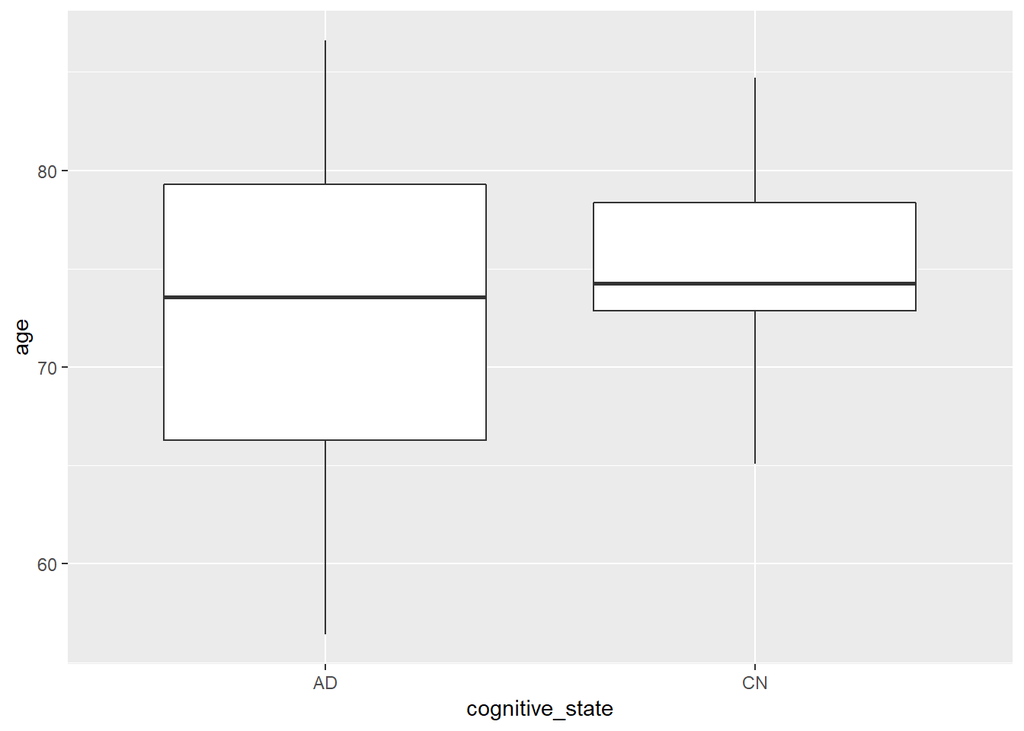

```r
library(ggplot2)
ggplot(data=data_bl, aes(x=cognitive_state, y=age)) +
    geom_boxplot()
```

```r
AD_patients <- data_bl%>%
  filter(cognitive_state=="AD")
mean(AD_patients$age)
```

```
## [1] 72.69
```

```r
CN_patients <- data_bl%>%
  filter(cognitive_state=="CN")
mean(CN_patients$age)
```

```
## [1] 75.00333
```

While the mean age between AD and CN patients were very similar, the overall distributions were more variable. This is most likely due to a small sample size of 30 patients in each group.

White Matter Content:

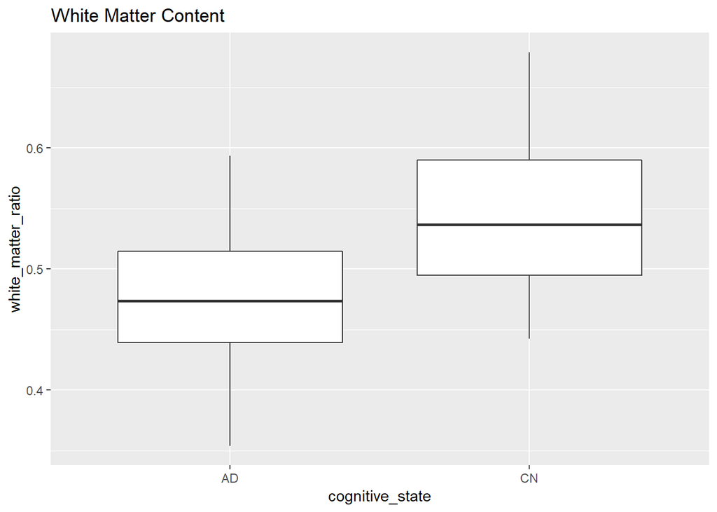

```r
ggplot(data=data_bl, aes(x=cognitive_state, y=white_matter_ratio)) +
    ggtitle("White Matter Content")+
    geom_boxplot()
```

While there is a noticable difference between AD and CN groups for the segmented white matter content, there is also a substantial overlap of the data. As a result, white matter content, if it does take place before grey matter degeneration, is not sufficient to fully predict Alzheimer’s Disease.

Total Boxplots:

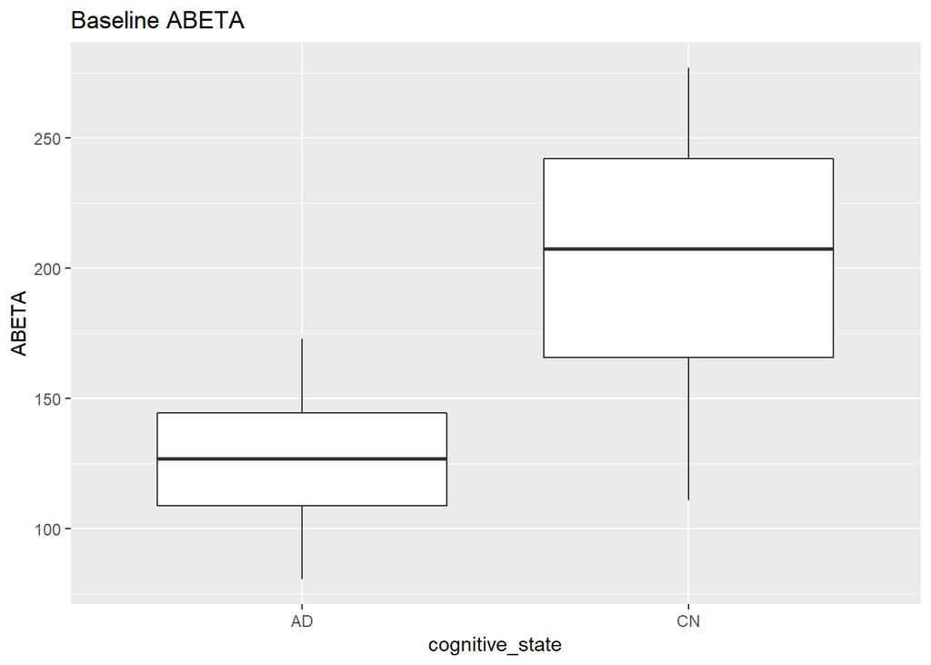

```r
## BL Plots
ggplot(data=data_bl, aes(x=cognitive_state, y=ABETA)) +
    ggtitle("Baseline ABETA")+
    geom_boxplot()
```

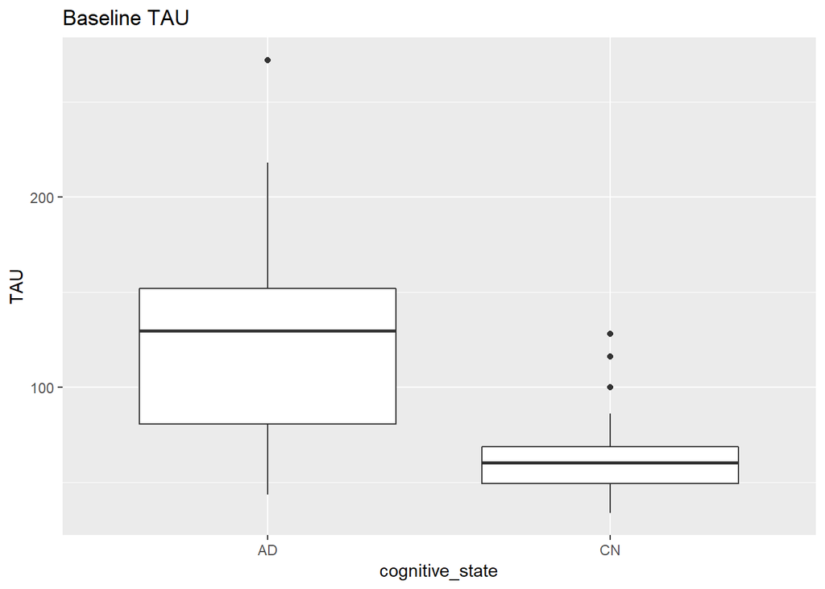

```r
ggplot(data=data_bl, aes(x=cognitive_state, y=TAU)) +
    ggtitle("Baseline TAU")+
    geom_boxplot()
```

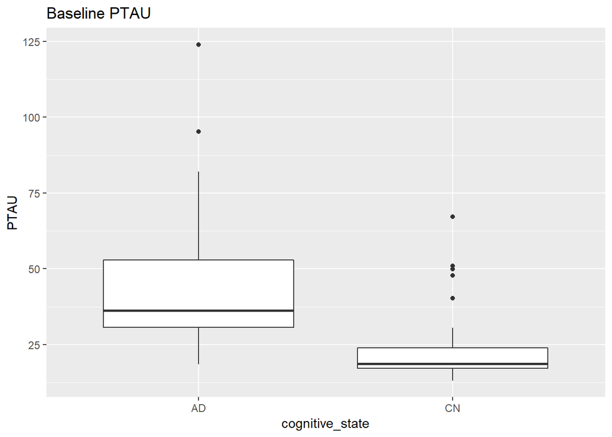

```r
ggplot(data=data_bl, aes(x=cognitive_state, y=PTAU)) +
    ggtitle("Baseline PTAU")+
    geom_boxplot()
```

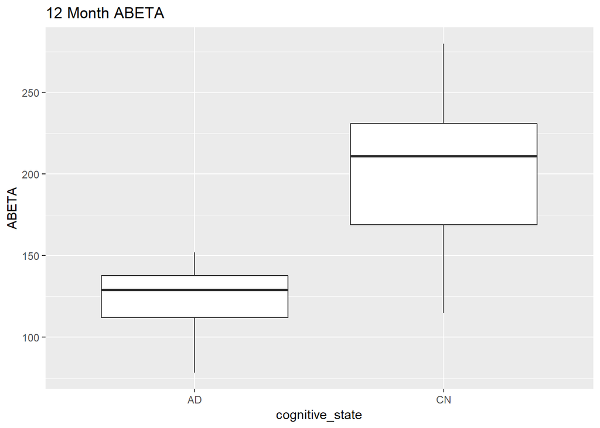

```r
## 12 month plots
ggplot(data=data_m12, aes(x=cognitive_state, y=ABETA)) +
    ggtitle("12 Month ABETA")+
    geom_boxplot()
```

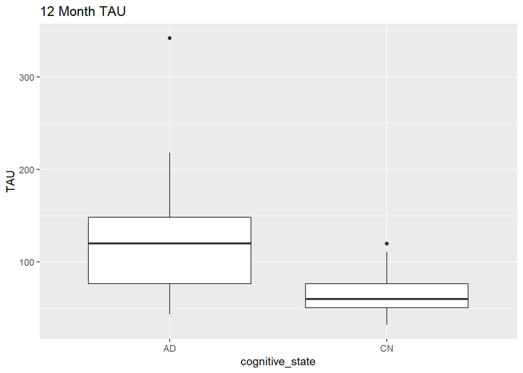

```r
ggplot(data=data_m12, aes(x=cognitive_state, y=TAU)) +
    ggtitle("12 Month TAU")+
    geom_boxplot()
```

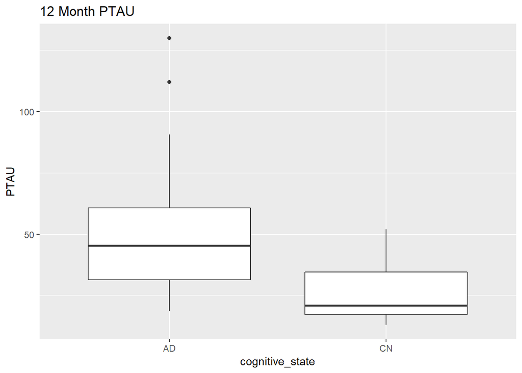

```r
ggplot(data=data_m12, aes(x=cognitive_state, y=PTAU)) +
    ggtitle("12 Month PTAU")+
    geom_boxplot()
```

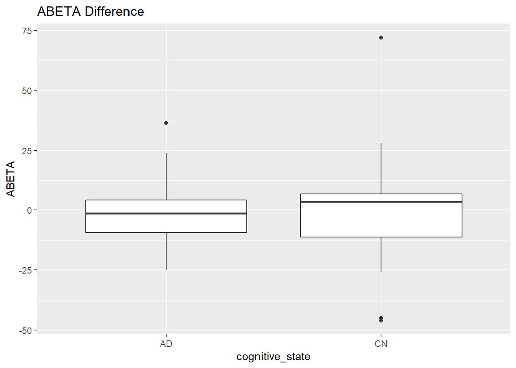

```r
## Difference Plots
ggplot(data=data_diff, aes(x=cognitive_state, y=ABETA)) +
    ggtitle("ABETA Difference")+
    geom_boxplot()
```

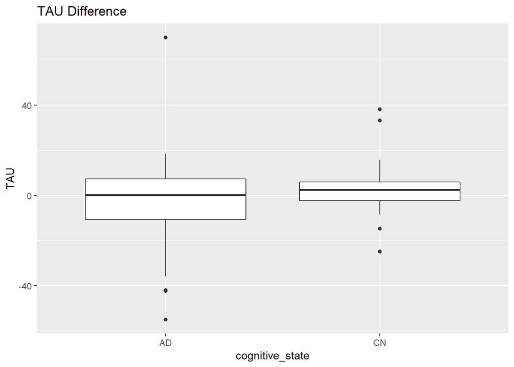

```r
ggplot(data=data_diff, aes(x=cognitive_state, y=TAU)) +
  ggtitle("TAU Difference")+
    geom_boxplot()
```

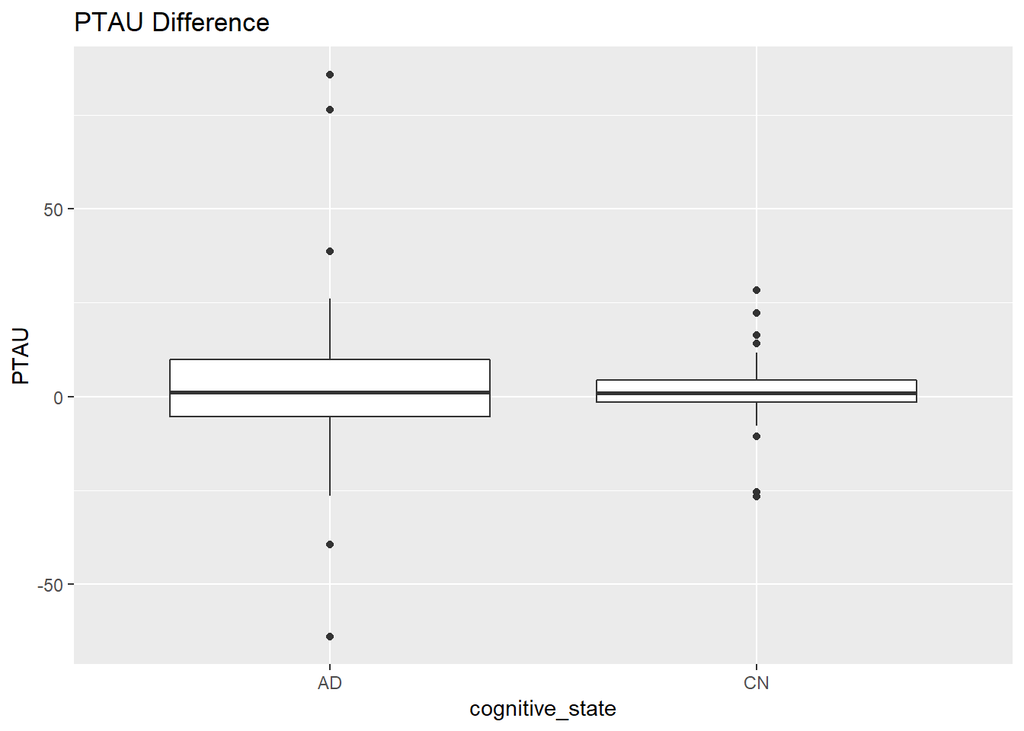

```r
ggplot(data=data_diff, aes(x=cognitive_state, y=PTAU)) +
  ggtitle("PTAU Difference")+
    geom_boxplot()
```

All boxplots for both baseline and 12 month data showed substantial differences between the AD and CN groups. However, the AD and CN groups were very similar for difference data.

Boxplots by gender:

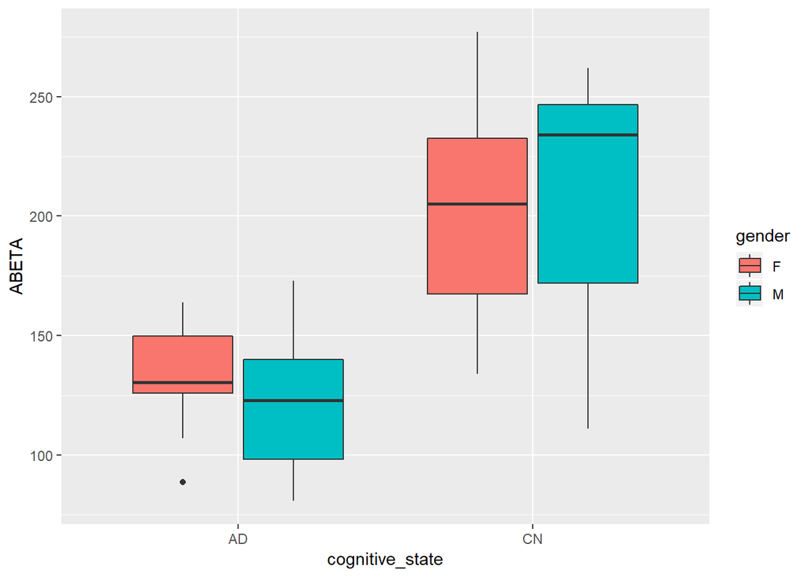

```r
## BL Plots
ggplot(data=data_bl, aes(x=cognitive_state, y=ABETA, fill=gender)) +
    geom_boxplot()
```

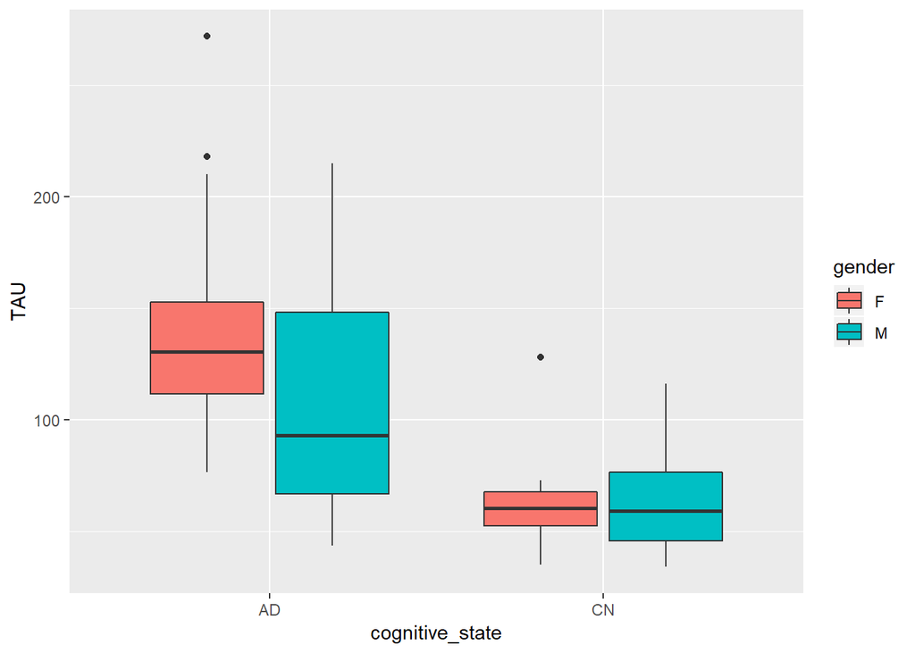

```r
ggplot(data=data_bl, aes(x=cognitive_state, y=TAU, fill=gender)) +
    geom_boxplot()
```